# Projet_Accident_de_la_route (1)

## 1.Collecte de données

```python
import numpy as np
import pandas as pd
import matplotlib.pyplot as plt
import seaborn as sns
```

Nous avons commencé par créer plusieurs dataframe par catégroie ( lieux, usagers , caractéristiques, et véhicules)

```python
# Créer une liste pour stocker les DataFrames de chaque fichier CSV
dfs = []

# Boucle pour lire et fusionner chaque fichier CSV
for year in range(2019, 2023):
    filename = f"lieux_{year}.csv"
    df = pd.read_csv(filename, sep=";")  # Lire le fichier CSV
    dfs.append(df)  # Ajouter le DataFrame à la liste

# Fusionner tous les DataFrames en un seul
merged_df = pd.concat(dfs, ignore_index=True)

# Enregistrer le DataFrame fusionné dans un nouveau fichier CSV
merged_df.to_csv("lieux_merged.csv", index=False)
```

```python
lieux = pd.read_csv('lieux_merged.csv')
lieux.tail()
```

|  | Num_Acc | catr | voie | v1 | v2 | circ | nbv | vosp | prof | pr | pr1 | plan | lartpc | larrout | surf | infra | situ | vma |
| --- | --- | --- | --- | --- | --- | --- | --- | --- | --- | --- | --- | --- | --- | --- | --- | --- | --- | --- |
| 218399 | 202200055298 | 3 | 71 | -1.0 | NaN | 2 | 2 | 0 | 2 | (1) | (1) | 1 | NaN | -1 | 1 | 0 | 8 | 80 |
| 218400 | 202200055299 | 3 | 973 | -1.0 | NaN | 2 | 2 | 0 | 1 | 29 | 0 | 2 | NaN | -1 | 1 | 0 | 3 | 80 |
| 218401 | 202200055300 | 3 | 22 | 0.0 | D | 2 | 2 | 0 | 1 | 39 | 553 | 2 | NaN | -1 | 7 | 0 | 3 | 80 |
| 218402 | 202200055301 | 3 | 18 | -1.0 | D | 2 | 2 | 0 | 1 | 30 | 125 | 1 | NaN | -1 | 1 | 0 | 1 | 80 |
| 218403 | 202200055302 | 3 | NaN | -1.0 | NaN | 3 | 4 | 0 | 1 | (1) | (1) | 1 | NaN | 4 | 1 | 0 | 1 | 70 |

```python
# Créer une liste pour stocker les DataFrames de chaque fichier CSV
dfs1 = []

# Boucle pour lire et fusionner chaque fichier CSV
for year in range(2019, 2023):
    filename = f"usagers_{year}.csv"
    df = pd.read_csv(filename, sep=";")  # Lire le fichier CSV
    dfs1.append(df)  # Ajouter le DataFrame à la liste

# Fusionner tous les DataFrames en un seul
merged_df1 = pd.concat(dfs1, ignore_index=True)

# Enregistrer le DataFrame fusionné dans un nouveau fichier CSV
merged_df1.to_csv("usagers_merged.csv", index=False)
```

```python
usagers = pd.read_csv('usagers_merged.csv')
usagers.tail()
```

|  | Num_Acc | id_vehicule | num_veh | place | catu | grav | sexe | an_nais | trajet | secu1 | secu2 | secu3 | locp | actp | etatp | id_usager |
| --- | --- | --- | --- | --- | --- | --- | --- | --- | --- | --- | --- | --- | --- | --- | --- | --- |
| 494177 | 202200055301 | 715 631 | A01 | 1 | 1 | 1 | 2 | 2002.0 | 5 | 1 | -1 | -1 | 0 | 0 | -1 | 968 230 |
| 494178 | 202200055301 | 715 631 | A01 | 8 | 2 | 3 | 2 | 2004.0 | 5 | 1 | -1 | -1 | 0 | 0 | -1 | 968 231 |
| 494179 | 202200055301 | 715 632 | B01 | 1 | 1 | 4 | 2 | 1953.0 | 5 | 1 | -1 | -1 | 0 | 0 | -1 | 968 232 |
| 494180 | 202200055302 | 715 629 | A01 | 1 | 1 | 3 | 1 | 1992.0 | 1 | 2 | 6 | -1 | -1 | -1 | -1 | 968 228 |
| 494181 | 202200055302 | 715 630 | B01 | 1 | 1 | 1 | 1 | 2000.0 | -1 | 1 | -1 | -1 | -1 | -1 | -1 | 968 229 |

```python
print(len(lieux))
print(len(usagers))
```

```
218404
494182
```

On renomme la colonne Accident_id du fichier caractéristiques.csv en Num_Acc car les deux colonnes correspondent à l'identifiant de l'accident.

```python
caracteristiques_2022= pd.read_csv('caracteristiques_2022.csv', sep=";")
caracteristiques_2022 = caracteristiques_2022.rename(columns={'Accident_Id': 'Num_Acc'})
```

```python
# Créer une liste pour stocker les DataFrames de chaque fichier CSV
dfs2 = []

# Boucle pour lire et fusionner chaque fichier CSV
for year in range(2019, 2022):
    filename = f"caracteristiques_{year}.csv"
    df = pd.read_csv(filename, sep=";")  # Lire le fichier CSV
    dfs2.append(df)  # Ajouter le DataFrame à la liste

dfs2.append(caracteristiques_2022)
# Fusionner tous les DataFrames en un seul
merged_df2= pd.concat(dfs2, ignore_index=True)


# Enregistrer le DataFrame fusionné dans un nouveau fichier CSV
merged_df2.to_csv("caracteristiques_merged.csv", index=False)
```

```python
caracteristiques = pd.read_csv('caracteristiques_merged.csv')
caracteristiques.tail()
```

|  | Num_Acc | jour | mois | an | hrmn | lum | dep | com | agg | int | atm | col | adr | lat | long |
| --- | --- | --- | --- | --- | --- | --- | --- | --- | --- | --- | --- | --- | --- | --- | --- |
| 218399 | 202200055298 | 1 | 1 | 2022 | 03:50 | 3 | 2B | 2B293 | 1 | 1 | 1 | 6 | D71 | 42,3101650000 | 9,4785830000 |
| 218400 | 202200055299 | 1 | 1 | 2022 | 07:20 | 3 | 84 | 84074 | 1 | 1 | 1 | 6 | D973 | 43,7531640000 | 5,2244760000 |
| 218401 | 202200055300 | 1 | 1 | 2022 | 04:27 | 3 | 74 | 74001 | 1 | 1 | 9 | 6 | D22 | 46,2825320000 | 6,7328060000 |
| 218402 | 202200055301 | 1 | 1 | 2022 | 08:40 | 1 | 81 | 81099 | 1 | 3 | 1 | 3 | Chemin Toulze | 43,9272650000 | 1,9156370000 |
| 218403 | 202200055302 | 1 | 3 | 2022 | 16:55 | 1 | 41 | 41018 | 2 | 1 | 1 | 2 | RD956 - Pont Charles De Gaulle | 47,5944040000 | 1,3533290000 |

```python
# Créer une liste pour stocker les DataFrames de chaque fichier CSV
dfs3 = []

# Boucle pour lire et fusionner chaque fichier CSV
for year in range(2019, 2023):
    filename = f"vehicules_{year}.csv"
    df = pd.read_csv(filename, sep=";")  # Lire le fichier CSV
    dfs3.append(df)  # Ajouter le DataFrame à la liste

# Fusionner tous les DataFrames en un seul
merged_df3= pd.concat(dfs3, ignore_index=True)

# Enregistrer le DataFrame fusionné dans un nouveau fichier CSV
merged_df3.to_csv("vehicules_merged.csv", index=False)
```

```python
vehicules = pd.read_csv('vehicules_merged.csv')
vehicules.tail()
```

|  | Num_Acc | id_vehicule | num_veh | senc | catv | obs | obsm | choc | manv | motor | occutc |
| --- | --- | --- | --- | --- | --- | --- | --- | --- | --- | --- | --- |
| 373579 | 202200055300 | 715 633 | A01 | 2 | 7 | 2 | 0 | 1 | 1 | 1 | NaN |
| 373580 | 202200055301 | 715 631 | A01 | 2 | 7 | 0 | 0 | 8 | 19 | 1 | NaN |
| 373581 | 202200055301 | 715 632 | B01 | 2 | 7 | 0 | 2 | 1 | 1 | 1 | NaN |
| 373582 | 202200055302 | 715 629 | A01 | 1 | 33 | 0 | 2 | 1 | 1 | 1 | NaN |
| 373583 | 202200055302 | 715 630 | B01 | 1 | 7 | 0 | 0 | 4 | 21 | 1 | NaN |

```python
df1 = usagers.merge(vehicules, how='left')
df1.tail()
```

|  | Num_Acc | id_vehicule | num_veh | place | catu | grav | sexe | an_nais | trajet | secu1 | ... | etatp | id_usager | senc | catv | obs | obsm | choc | manv | motor | occutc |
| --- | --- | --- | --- | --- | --- | --- | --- | --- | --- | --- | --- | --- | --- | --- | --- | --- | --- | --- | --- | --- | --- |
| 494177 | 202200055301 | 715 631 | A01 | 1 | 1 | 1 | 2 | 2002.0 | 5 | 1 | ... | -1 | 968 230 | 2 | 7 | 0 | 0 | 8 | 19 | 1 | NaN |
| 494178 | 202200055301 | 715 631 | A01 | 8 | 2 | 3 | 2 | 2004.0 | 5 | 1 | ... | -1 | 968 231 | 2 | 7 | 0 | 0 | 8 | 19 | 1 | NaN |
| 494179 | 202200055301 | 715 632 | B01 | 1 | 1 | 4 | 2 | 1953.0 | 5 | 1 | ... | -1 | 968 232 | 2 | 7 | 0 | 2 | 1 | 1 | 1 | NaN |
| 494180 | 202200055302 | 715 629 | A01 | 1 | 1 | 3 | 1 | 1992.0 | 1 | 2 | ... | -1 | 968 228 | 1 | 33 | 0 | 2 | 1 | 1 | 1 | NaN |
| 494181 | 202200055302 | 715 630 | B01 | 1 | 1 | 1 | 1 | 2000.0 | -1 | 1 | ... | -1 | 968 229 | 1 | 7 | 0 | 0 | 4 | 21 | 1 | NaN |

5 rows × 24 columns

Puis nous avons mergé tous les dataframes au dataframe Usager car il contenait la colonne Num_Acc repris pour chacun des usagers ayant été impliqué dans un accident. Ainsi on est sûr de recupérer le maximum de données possibles sur tous les accidents et tous les usagers

```python
df2 = df1.merge(lieux, how='left')
df3 = df2.merge(caracteristiques,  how='left')
```

```python
df=df3
df.tail()
```

|  | Num_Acc | id_vehicule | num_veh | place | catu | grav | sexe | an_nais | trajet | secu1 | ... | lum | dep | com | agg | int | atm | col | adr | lat | long |
| --- | --- | --- | --- | --- | --- | --- | --- | --- | --- | --- | --- | --- | --- | --- | --- | --- | --- | --- | --- | --- | --- |
| 494177 | 202200055301 | 715 631 | A01 | 1 | 1 | 1 | 2 | 2002.0 | 5 | 1 | ... | 1 | 81 | 81099 | 1 | 3 | 1 | 3 | Chemin Toulze | 43,9272650000 | 1,9156370000 |
| 494178 | 202200055301 | 715 631 | A01 | 8 | 2 | 3 | 2 | 2004.0 | 5 | 1 | ... | 1 | 81 | 81099 | 1 | 3 | 1 | 3 | Chemin Toulze | 43,9272650000 | 1,9156370000 |
| 494179 | 202200055301 | 715 632 | B01 | 1 | 1 | 4 | 2 | 1953.0 | 5 | 1 | ... | 1 | 81 | 81099 | 1 | 3 | 1 | 3 | Chemin Toulze | 43,9272650000 | 1,9156370000 |
| 494180 | 202200055302 | 715 629 | A01 | 1 | 1 | 3 | 1 | 1992.0 | 1 | 2 | ... | 1 | 41 | 41018 | 2 | 1 | 1 | 2 | RD956 - Pont Charles De Gaulle | 47,5944040000 | 1,3533290000 |
| 494181 | 202200055302 | 715 630 | B01 | 1 | 1 | 1 | 1 | 2000.0 | -1 | 1 | ... | 1 | 41 | 41018 | 2 | 1 | 1 | 2 | RD956 - Pont Charles De Gaulle | 47,5944040000 | 1,3533290000 |

5 rows × 55 columns

## 2. Exploration et nettoyage des données

### 2.1 Nettoyage des données( gestion des valeurs manquantes et abérentes)

```python
df['grav'].describe()
```

```
count    494182.000000
mean          2.531620
std           1.376507
min          -1.000000
25%           1.000000
50%           3.000000
75%           4.000000
max           4.000000
Name: grav, dtype: float64
```

Observations:

la Colonne vma( vitesse maximal autorisée) présentes des valeurs abérantes: négatives, ou des vitesses qui n'existent pas dans la réglementations routière en vigueur.

On va commencer par vérifier que les valeurs des modalités de chaque variables correspond à celle fournit par la documentation. Pour des valeurs qui ne correspondrait pas ,soit nous allons supprimer les lignes les contenant s'il représente une part insignifiante du jeux de données , ou les remplacer par non renseigné NR.

```python
df['grav'].value_counts()
```

```
 1    207354
 4    197494
 3     75986
 2     13047
-1       301
Name: grav, dtype: int64
```

```python
 #enlever ceux avec la modlité -1 car elle ne correspond à aucune description dans la documentation de la base de données et représente un jeux de données très faible sur l'ensemble du jeux de données.
df['grav'] = df['grav'].replace({-1: 1})
```

```python
df['grav'].value_counts()
```

```
1    207655
4    197494
3     75986
2     13047
Name: grav, dtype: int64
```

```python
df['sexe'].value_counts()
```

```
 1    333872
 2    154504
-1      5806
Name: sexe, dtype: int64
```

On va garder la modalité -1 comme non renseigné

```python
df['sexe'].value_counts()
```

```
 1    333872
 2    154504
-1      5806
Name: sexe, dtype: int64
```

```python
df['vma'].value_counts()
```

```
 50     253051
 80      70029
 30      48713
 90      38526
 70      37818
 110     20459
 130     13116
-1        7151
 60       1379
 20       1204
 10        953
 40        401
 15        235
 5         217
 45        176
```

[output cut: 33 more lines]

```python
# Liste des vitesses à supprimer
vitesses_a_supprimer = [1,-1,2,500,6,35,3,300, 900, 4, 700, 7, 901, 65, 12, 42, 560, 502, 9, 75, 520, 8, 55, 120, 180, 0, 501, 770, 140, 800, 600]

# Supprimer les lignes où les vitesses sont présentes dans la liste
df = df[~df['vma'].isin(vitesses_a_supprimer)]
```

```python
df['vma'].value_counts()
```

```
50     253051
80      70029
30      48713
90      38526
70      37818
110     20459
130     13116
60       1379
20       1204
10        953
40        401
15        235
5         217
45        176
25        157
100        77
Name: vma, dtype: int64
```

```python
df['catr'].value_counts()
```

```
4    196733
3    176705
1     56319
2     34610
7     15923
6      2980
9      2817
5       424
Name: catr, dtype: int64
```

```python
df['int'].value_counts()
```

```
 1    311407
 2     63402
 3     52279
 9     21071
 6     18145
 4     11070
 7      5260
 5      2972
 8       886
-1        19
Name: int, dtype: int64
```

```python
#enlever ceux avec la modlité -1
df['int'] = df['int'].replace({-1:1})
```

```python
df['int'].value_counts()
```

```
1    311426
2     63402
3     52279
9     21071
6     18145
4     11070
7      5260
5      2972
8       886
Name: int, dtype: int64
```

```python
df['catr'].value_counts()
```

```
4    196733
3    176705
1     56319
2     34610
7     15923
6      2980
9      2817
5       424
Name: catr, dtype: int64
```

###### Vérification des valeurs manquantes.

```python
df.isna().sum(axis = 0)
```

```
Num_Acc             0
id_vehicule         0
num_veh             0
place               0
catu                0
grav                0
sexe                0
an_nais          5879
trajet              0
secu1               0
secu2               0
secu3               0
locp                0
actp                0
etatp               0
id_usager      234556
senc                0
catv                0
obs                 0
obsm                0
choc                0
manv                0
motor               0
occutc         480343
catr                0
voie            45202
v1              23136
v2             448206
circ                0
nbv                 0
vosp                0
prof                0
pr                  0
pr1                 0
plan                0
lartpc         485434
larrout        130072
surf                0
infra               0
situ                0
vma                 0
jour                0
mois                0
an                  0
hrmn                0
lum                 0
dep                 0
com                 0
agg                 0
int                 0
atm                 0
col                 0
adr              5924
lat                 0
long                0
dtype: int64
```

On remarque qu'il y a plusieurs variables qui ont un nombre de valeurs manquantes sur plus de 90% des enregistrements. On va les supprimer

```python
print(df['an_nais'].describe())
df['an_nais'].value_counts()
```

```
count    480632.000000
mean       1982.060720
std          18.940116
min        1900.000000
25%        1969.000000
50%        1986.000000
75%        1997.000000
max        2022.000000
Name: an_nais, dtype: float64
```

```
2000.0    14691
1999.0    13836
2001.0    13202
1998.0    12988
1997.0    12261
          ...
1919.0        4
1913.0        4
1910.0        3
1911.0        1
1912.0        1
Name: an_nais, Length: 110, dtype: int64
```

```python
df=df.drop(columns=['occutc','v1', 'v2',
                    'lartpc','larrout','id_usager','voie','adr'])
```

```python
df=df.dropna()
```

```python
df.isna().sum(axis = 0)
```

```
Num_Acc        0
id_vehicule    0
num_veh        0
place          0
catu           0
grav           0
sexe           0
an_nais        0
trajet         0
secu1          0
secu2          0
secu3          0
locp           0
actp           0
etatp          0
senc           0
catv           0
obs            0
obsm           0
choc           0
manv           0
motor          0
catr           0
circ           0
nbv            0
vosp           0
prof           0
pr             0
pr1            0
plan           0
surf           0
infra          0
situ           0
vma            0
jour           0
mois           0
an             0
hrmn           0
lum            0
dep            0
com            0
agg            0
int            0
atm            0
col            0
lat            0
long           0
dtype: int64
```

Il n'ya plus de valeurs manquantes dans notre jeux de données

```python
df.head()
```

|  | Num_Acc | id_vehicule | num_veh | place | catu | grav | sexe | an_nais | trajet | secu1 | ... | hrmn | lum | dep | com | agg | int | atm | col | lat | long |
| --- | --- | --- | --- | --- | --- | --- | --- | --- | --- | --- | --- | --- | --- | --- | --- | --- | --- | --- | --- | --- | --- |
| 0 | 201900000001 | 138 306 524 | B01 | 2 | 2 | 4 | 2 | 2002.0 | 0 | 1 | ... | 01:30 | 4 | 93 | 93053 | 1 | 1 | 1 | 2 | 48,8962100 | 2,4701200 |
| 1 | 201900000001 | 138 306 524 | B01 | 1 | 1 | 4 | 2 | 1993.0 | 5 | 1 | ... | 01:30 | 4 | 93 | 93053 | 1 | 1 | 1 | 2 | 48,8962100 | 2,4701200 |
| 2 | 201900000001 | 138 306 525 | A01 | 1 | 1 | 1 | 1 | 1959.0 | 0 | 1 | ... | 01:30 | 4 | 93 | 93053 | 1 | 1 | 1 | 2 | 48,8962100 | 2,4701200 |
| 3 | 201900000002 | 138 306 523 | A01 | 1 | 1 | 4 | 2 | 1994.0 | 0 | 1 | ... | 02:50 | 3 | 93 | 93066 | 1 | 1 | 1 | 6 | 48,9307000 | 2,3688000 |
| 4 | 201900000003 | 138 306 520 | A01 | 1 | 1 | 1 | 1 | 1996.0 | 0 | 1 | ... | 15:15 | 1 | 92 | 92036 | 1 | 1 | 1 | 4 | 48,9358718 | 2,3191744 |

5 rows × 47 columns

```python
len(df)
```

```
480632
```

```python
df.info()
```

```
<class 'pandas.core.frame.DataFrame'>
Int64Index: 480632 entries, 0 to 494181
Data columns (total 47 columns):
 #   Column       Non-Null Count   Dtype
---  ------       --------------   -----
 0   Num_Acc      480632 non-null  int64
 1   id_vehicule  480632 non-null  object
 2   num_veh      480632 non-null  object
 3   place        480632 non-null  int64
 4   catu         480632 non-null  int64
 5   grav         480632 non-null  int64
 6   sexe         480632 non-null  int64
 7   an_nais      480632 non-null  float64
 8   trajet       480632 non-null  int64
 9   secu1        480632 non-null  int64
```

[output cut: 39 more lines]

Nous allons continuer à vérifier si les valeurs de chaque variable correspondent aux modalités de la documentation.

```python
df['lum'].value_counts()
```

```
 1    324634
 5     73863
 3     47321
 2     30648
 4      4164
-1         2
Name: lum, dtype: int64
```

```python
df['pr1'].value_counts()
```

```
0       164294
(1)     113043
500      17708
1        15307
100       9930
         ...
3257         1
3600         1
1192         1
1606         1
1307         1
Name: pr1, Length: 1464, dtype: int64
```

```python
df['circ'].value_counts()
```

```
 2    291735
 1     84318
 3     76548
-1     24905
 4      3126
Name: circ, dtype: int64
```

```python
df['prof'].value_counts()
```

```
 1    389866
 2     75485
 3      8288
 4      6971
-1        22
Name: prof, dtype: int64
```

```python
df['pr'].value_counts()
```

```
0       147511
(1)     111375
1        29907
2        10821
3         9139
         ...
511          1
982          1
4770         1
442          1
325          1
Name: pr, Length: 631, dtype: int64
```

```python
df['locp'].value_counts()
```

```
 0    232895
-1    210488
 3     11657
 2      8330
 4      5647
 1      5380
 5      2850
 9      1749
 6      1078
 8       517
 7        41
Name: locp, dtype: int64
```

```python
df['locp'] = df['locp'].replace({'A': 10, 'B':11})
df['pr'] = df['pr'].replace({'(1)':-1})
```

```python
#Nous allons enlever les colonnes avec les identifiants
df=df.drop(columns=['Num_Acc', 'id_vehicule', 'num_veh'])
```

```python
df.info()
```

```
<class 'pandas.core.frame.DataFrame'>
Int64Index: 480632 entries, 0 to 494181
Data columns (total 44 columns):
 #   Column   Non-Null Count   Dtype
---  ------   --------------   -----
 0   place    480632 non-null  int64
 1   catu     480632 non-null  int64
 2   grav     480632 non-null  int64
 3   sexe     480632 non-null  int64
 4   an_nais  480632 non-null  float64
 5   trajet   480632 non-null  int64
 6   secu1    480632 non-null  int64
 7   secu2    480632 non-null  int64
 8   secu3    480632 non-null  int64
 9   locp     480632 non-null  int64
```

[output cut: 36 more lines]

On remarque qu'il y a des variables de type réelles et d'autres de type object.

### 2.2 Transformation de données

```python
# Nous allons définir une fonction pour convertir le format heure:minute en nombre flottant
def convert_to_float(time_str):
    # Diviser l'heure et les minutes
    hour, minute = map(int, time_str.split(':'))
    # Calculer le nombre flottant en ajoutant les heures et les minutes converties en fraction
    return hour + minute / 60
```

```python
# Appliquer la fonction à la colonne 'hrmn' à l'aide de la méthode apply
df['hrmn'] = df['hrmn'].apply(lambda x: convert_to_float(x))


#Nous allons convertir la variables heures en variable numérique
df['hrmn'] = pd.to_numeric(df['hrmn'], errors='coerce')
```

```python
df.info()
```

```
<class 'pandas.core.frame.DataFrame'>
Int64Index: 480632 entries, 0 to 494181
Data columns (total 44 columns):
 #   Column   Non-Null Count   Dtype
---  ------   --------------   -----
 0   place    480632 non-null  int64
 1   catu     480632 non-null  int64
 2   grav     480632 non-null  int64
 3   sexe     480632 non-null  int64
 4   an_nais  480632 non-null  float64
 5   trajet   480632 non-null  int64
 6   secu1    480632 non-null  int64
 7   secu2    480632 non-null  int64
 8   secu3    480632 non-null  int64
 9   locp     480632 non-null  int64
```

[output cut: 36 more lines]

```python
#Nous allons transformer les variables latitude longitudes en type float, car ce sont des variables continnuelles.
df['lat'] = df['lat'].str.replace(',', '.').astype(float)
df['long'] = df['long'].str.replace(',', '.').astype(float)
```

```python
df['vma'] = df['vma'].astype(float)
```

```python
df[df.columns[30:]]
```

|  | vma | jour | mois | an | hrmn | lum | dep | com | agg | int | atm | col | lat | long |
| --- | --- | --- | --- | --- | --- | --- | --- | --- | --- | --- | --- | --- | --- | --- |
| 0 | 70.0 | 30 | 11 | 2019 | 1.500000 | 4 | 93 | 93053 | 1 | 1 | 1 | 2 | 48.896210 | 2.470120 |
| 1 | 70.0 | 30 | 11 | 2019 | 1.500000 | 4 | 93 | 93053 | 1 | 1 | 1 | 2 | 48.896210 | 2.470120 |
| 2 | 70.0 | 30 | 11 | 2019 | 1.500000 | 4 | 93 | 93053 | 1 | 1 | 1 | 2 | 48.896210 | 2.470120 |
| 3 | 70.0 | 30 | 11 | 2019 | 2.833333 | 3 | 93 | 93066 | 1 | 1 | 1 | 6 | 48.930700 | 2.368800 |
| 4 | 90.0 | 28 | 11 | 2019 | 15.250000 | 1 | 92 | 92036 | 1 | 1 | 1 | 4 | 48.935872 | 2.319174 |
| ... | ... | ... | ... | ... | ... | ... | ... | ... | ... | ... | ... | ... | ... | ... |
| 494177 | 80.0 | 1 | 1 | 2022 | 8.666667 | 1 | 81 | 81099 | 1 | 3 | 1 | 3 | 43.927265 | 1.915637 |
| 494178 | 80.0 | 1 | 1 | 2022 | 8.666667 | 1 | 81 | 81099 | 1 | 3 | 1 | 3 | 43.927265 | 1.915637 |
| 494179 | 80.0 | 1 | 1 | 2022 | 8.666667 | 1 | 81 | 81099 | 1 | 3 | 1 | 3 | 43.927265 | 1.915637 |
| 494180 | 70.0 | 1 | 3 | 2022 | 16.916667 | 1 | 41 | 41018 | 2 | 1 | 1 | 2 | 47.594404 | 1.353329 |
| 494181 | 70.0 | 1 | 3 | 2022 | 16.916667 | 1 | 41 | 41018 | 2 | 1 | 1 | 2 | 47.594404 | 1.353329 |

480632 rows × 14 columns

```python
max(df['hrmn'].unique())
```

```
23.983333333333334
```

```python
min(df['hrmn'].unique())
```

```
0.0
```

Les deux valeurs affichées au dessus sont très proche en réalité, il faut qu'on puisse trouver une méthode pour les rapprocher

Nous allons normaliser ces heures de telles sortent qu'elles soient représenter sur un cercle trigonométrique :

Cette méthode aura pour avantage de:

-Gérer les problèmes de discontinuités : Les valeurs horaires comme 23.98 et 0.0, qui sont proches sur un cercle de 24 heures, sont représentées de manière continue en utilisant les coordonnées circulaires.

-Améliorer notre modèle de machine learning car il prendre en compte des valeurs proches.

```python
# Convertir les heures en radians
df['hrmn_radians'] = (df['hrmn'] / 24) * 2 * np.pi

# Calculer les composantes sin et cos
df['heure_sin'] = np.sin(df['hrmn_radians'])
df['heure_cos'] = np.cos(df['hrmn_radians'])
```

```python
df[df.columns[30:]]
```

|  | vma | jour | mois | an | hrmn | lum | dep | com | agg | int | atm | col | lat | long | hrmn_radians | heure_sin | heure_cos |
| --- | --- | --- | --- | --- | --- | --- | --- | --- | --- | --- | --- | --- | --- | --- | --- | --- | --- |
| 0 | 70.0 | 30 | 11 | 2019 | 1.500000 | 4 | 93 | 93053 | 1 | 1 | 1 | 2 | 48.896210 | 2.470120 | 0.392699 | 0.382683 | 0.923880 |
| 1 | 70.0 | 30 | 11 | 2019 | 1.500000 | 4 | 93 | 93053 | 1 | 1 | 1 | 2 | 48.896210 | 2.470120 | 0.392699 | 0.382683 | 0.923880 |
| 2 | 70.0 | 30 | 11 | 2019 | 1.500000 | 4 | 93 | 93053 | 1 | 1 | 1 | 2 | 48.896210 | 2.470120 | 0.392699 | 0.382683 | 0.923880 |
| 3 | 70.0 | 30 | 11 | 2019 | 2.833333 | 3 | 93 | 93066 | 1 | 1 | 1 | 6 | 48.930700 | 2.368800 | 0.741765 | 0.675590 | 0.737277 |
| 4 | 90.0 | 28 | 11 | 2019 | 15.250000 | 1 | 92 | 92036 | 1 | 1 | 1 | 4 | 48.935872 | 2.319174 | 3.992441 | -0.751840 | -0.659346 |
| ... | ... | ... | ... | ... | ... | ... | ... | ... | ... | ... | ... | ... | ... | ... | ... | ... | ... |
| 494177 | 80.0 | 1 | 1 | 2022 | 8.666667 | 1 | 81 | 81099 | 1 | 3 | 1 | 3 | 43.927265 | 1.915637 | 2.268928 | 0.766044 | -0.642788 |
| 494178 | 80.0 | 1 | 1 | 2022 | 8.666667 | 1 | 81 | 81099 | 1 | 3 | 1 | 3 | 43.927265 | 1.915637 | 2.268928 | 0.766044 | -0.642788 |
| 494179 | 80.0 | 1 | 1 | 2022 | 8.666667 | 1 | 81 | 81099 | 1 | 3 | 1 | 3 | 43.927265 | 1.915637 | 2.268928 | 0.766044 | -0.642788 |
| 494180 | 70.0 | 1 | 3 | 2022 | 16.916667 | 1 | 41 | 41018 | 2 | 1 | 1 | 2 | 47.594404 | 1.353329 | 4.428773 | -0.960050 | -0.279829 |
| 494181 | 70.0 | 1 | 3 | 2022 | 16.916667 | 1 | 41 | 41018 | 2 | 1 | 1 | 2 | 47.594404 | 1.353329 | 4.428773 | -0.960050 | -0.279829 |

480632 rows × 17 columns

```python
df['grav'].value_counts()
```

```
1    198920
4    195095
3     73943
2     12674
Name: grav, dtype: int64
```

Dans la documentation la colonne gravité a des modalités définies comme suit : 1 - Indemne 2 - Tué 3 - Blessé hospitalisé 4 - Blessé léger

On va renommer les chiffres par niveau de gravité: 1 - Indemne 2 - Blessé léger 3 - Blessé hospitalisé 4 - Tué

```python
df['grav'] = df['grav'].replace({2:4, 4:2})
```

```python
df['grav'].value_counts()
```

```
1    198920
2    195095
3     73943
4     12674
Name: grav, dtype: int64
```

```python
df.info()
```

```
<class 'pandas.core.frame.DataFrame'>
Int64Index: 480632 entries, 0 to 494181
Data columns (total 47 columns):
 #   Column        Non-Null Count   Dtype
---  ------        --------------   -----
 0   place         480632 non-null  int64
 1   catu          480632 non-null  int64
 2   grav          480632 non-null  int64
 3   sexe          480632 non-null  int64
 4   an_nais       480632 non-null  float64
 5   trajet        480632 non-null  int64
 6   secu1         480632 non-null  int64
 7   secu2         480632 non-null  int64
 8   secu3         480632 non-null  int64
 9   locp          480632 non-null  int64
```

[output cut: 39 more lines]

```python
df['nbv'].value_counts()
```

```
2          242847
4           52671
2           43480
1           38486
3           34342
6           12305
0            9646
4            9200
5            7677
1            6705
3            6269
8            4096
-1           2965
6            2238
7            1451
```

[output cut: 16 more lines]

```python
df['actp'].value_counts()
```

```
0      263794
 -1    179467
3       27584
9        2430
1        2403
5        1502
B        1192
2        1126
4         513
A         409
6         104
7          57
8          51
Name: actp, dtype: int64
```

```python
# Exclure les lignes contenant '#ERREUR', 'A' et 'B' dans la colonne 'nbv'
df = df[~df['actp'].isin(['#ERREUR', 'A', 'B'])]
```

```python
df['nbv'].unique()
```

```
array([10, 2, 8, 5, 3, 4, 6, 1, 7, 0, -1, 9, 11, 12, '2', '8', '6', '4',
       '5', '0', '7', '3', '1', ' -1', '12', '10', '9', '#ERREUR', '11',
       '-1'], dtype=object)
```

```python
df['nbv'] = df['nbv'].replace({'#ERREUR':-1})
```

```python
df['nbv'] = df['nbv'].replace({' -1':'-1'})
```

```python
df['pr1'].value_counts()
```

```
0       163522
(1)     112606
500      17675
1        15237
100       9899
         ...
1175         1
3261         1
1035         1
1791         1
1307         1
Name: pr1, Length: 1464, dtype: int64
```

```python
# On va remplacer (1) par -1 , que nous allons considérer comme non renseigné.
df['pr1'] = df['pr1'].replace({'(1)':-1})
```

```python
df['dep'].unique()
```

```
array(['93', '92', '94', '87', '69', '38', '34', '13', '988', '976',
       '974', '972', '2B', '91', '86', '83', '80', '78', '77', '76', '72',
       '71', '67', '66', '64', '60', '51', '50', '49', '45', '37', '35',
       '33', '31', '30', '29', '22', '19', '18', '17', '74', '81', '2',
       '59', '95', '63', '62', '973', '2A', '84', '9', '73', '43', '10',
       '36', '16', '7', '21', '40', '24', '4', '85', '27', '28', '52',
       '68', '42', '82', '11', '987', '44', '61', '14', '56', '58', '54',
       '47', '41', '3', '75', '1', '57', '32', '39', '15', '23', '6', '5',
       '26', '48', '986', '971', '89', '25', '12', '88', '65', '53', '70',
       '46', '90', '8', '79', '977', '55', '978', '975', '06', '03', '07',
       '01', '08', '02', '05', '04', '09'], dtype=object)
```

```python
df
```

|  | place | catu | grav | sexe | an_nais | trajet | secu1 | secu2 | secu3 | locp | ... | com | agg | int | atm | col | lat | long | hrmn_radians | heure_sin | heure_cos |
| --- | --- | --- | --- | --- | --- | --- | --- | --- | --- | --- | --- | --- | --- | --- | --- | --- | --- | --- | --- | --- | --- |
| 0 | 2 | 2 | 2 | 2 | 2002.0 | 0 | 1 | 0 | -1 | -1 | ... | 93053 | 1 | 1 | 1 | 2 | 48.896210 | 2.470120 | 0.392699 | 0.382683 | 0.923880 |
| 1 | 1 | 1 | 2 | 2 | 1993.0 | 5 | 1 | 0 | -1 | -1 | ... | 93053 | 1 | 1 | 1 | 2 | 48.896210 | 2.470120 | 0.392699 | 0.382683 | 0.923880 |
| 2 | 1 | 1 | 1 | 1 | 1959.0 | 0 | 1 | 0 | -1 | -1 | ... | 93053 | 1 | 1 | 1 | 2 | 48.896210 | 2.470120 | 0.392699 | 0.382683 | 0.923880 |
| 3 | 1 | 1 | 2 | 2 | 1994.0 | 0 | 1 | 0 | -1 | -1 | ... | 93066 | 1 | 1 | 1 | 6 | 48.930700 | 2.368800 | 0.741765 | 0.675590 | 0.737277 |
| 4 | 1 | 1 | 1 | 1 | 1996.0 | 0 | 1 | 0 | -1 | -1 | ... | 92036 | 1 | 1 | 1 | 4 | 48.935872 | 2.319174 | 3.992441 | -0.751840 | -0.659346 |
| ... | ... | ... | ... | ... | ... | ... | ... | ... | ... | ... | ... | ... | ... | ... | ... | ... | ... | ... | ... | ... | ... |
| 494177 | 1 | 1 | 1 | 2 | 2002.0 | 5 | 1 | -1 | -1 | 0 | ... | 81099 | 1 | 3 | 1 | 3 | 43.927265 | 1.915637 | 2.268928 | 0.766044 | -0.642788 |
| 494178 | 8 | 2 | 3 | 2 | 2004.0 | 5 | 1 | -1 | -1 | 0 | ... | 81099 | 1 | 3 | 1 | 3 | 43.927265 | 1.915637 | 2.268928 | 0.766044 | -0.642788 |
| 494179 | 1 | 1 | 2 | 2 | 1953.0 | 5 | 1 | -1 | -1 | 0 | ... | 81099 | 1 | 3 | 1 | 3 | 43.927265 | 1.915637 | 2.268928 | 0.766044 | -0.642788 |
| 494180 | 1 | 1 | 3 | 1 | 1992.0 | 1 | 2 | 6 | -1 | -1 | ... | 41018 | 2 | 1 | 1 | 2 | 47.594404 | 1.353329 | 4.428773 | -0.960050 | -0.279829 |
| 494181 | 1 | 1 | 1 | 1 | 2000.0 | -1 | 1 | -1 | -1 | -1 | ... | 41018 | 2 | 1 | 1 | 2 | 47.594404 | 1.353329 | 4.428773 | -0.960050 | -0.279829 |

479031 rows × 47 columns

```python
# Sélectionner les colonnes de type 'object'
object_columns = df.select_dtypes(include=['object']).columns
object_columns
```

```
Index(['actp', 'nbv', 'pr', 'pr1', 'dep', 'com'], dtype='object')
```

On va bien vérifier que toutes ces variables de type objet sont des string afin d'éviter des erreurs de labélisation plus tard

```python
# Convertir les variables spécifiées en chaînes de caractères
variables_to_convert = ['actp', 'nbv', 'pr', 'pr1', 'dep', 'com']
df[variables_to_convert] = df[variables_to_convert].astype(str)
```

```python
df['dep'].unique()
```

```
array(['93', '92', '94', '87', '69', '38', '34', '13', '988', '976',
       '974', '972', '2B', '91', '86', '83', '80', '78', '77', '76', '72',
       '71', '67', '66', '64', '60', '51', '50', '49', '45', '37', '35',
       '33', '31', '30', '29', '22', '19', '18', '17', '74', '81', '2',
       '59', '95', '63', '62', '973', '2A', '84', '9', '73', '43', '10',
       '36', '16', '7', '21', '40', '24', '4', '85', '27', '28', '52',
       '68', '42', '82', '11', '987', '44', '61', '14', '56', '58', '54',
       '47', '41', '3', '75', '1', '57', '32', '39', '15', '23', '6', '5',
       '26', '48', '986', '971', '89', '25', '12', '88', '65', '53', '70',
       '46', '90', '8', '79', '977', '55', '978', '975', '06', '03', '07',
       '01', '08', '02', '05', '04', '09'], dtype=object)
```

```python
#on stocke le nouveau dataframe avec toutes les varaibles labélisées
df.to_csv('stats_data.csv', index=False)
```

### 2.2.1 Encodage des variables catégorielles

```python
df = pd.read_csv('stats_data.csv', sep=",")
```

```python
df.info()
```

```
<class 'pandas.core.frame.DataFrame'>
RangeIndex: 479031 entries, 0 to 479030
Data columns (total 47 columns):
 #   Column        Non-Null Count   Dtype
---  ------        --------------   -----
 0   place         479031 non-null  int64
 1   catu          479031 non-null  int64
 2   grav          479031 non-null  int64
 3   sexe          479031 non-null  int64
 4   an_nais       479031 non-null  float64
 5   trajet        479031 non-null  int64
 6   secu1         479031 non-null  int64
 7   secu2         479031 non-null  int64
 8   secu3         479031 non-null  int64
 9   locp          479031 non-null  int64
```

[output cut: 39 more lines]

##### 2.2.1.1 Encodage par fréquence d'apparution

```python
categorical_vars = ['place', 'catu', 'sexe', 'trajet', 'secu1', 'secu2',
       'secu3', 'locp', 'actp', 'etatp', 'senc', 'catv', 'obs', 'obsm', 'choc',
       'manv', 'motor', 'catr', 'circ', 'vosp', 'prof', 'pr', 'pr1',
       'plan', 'surf', 'infra', 'situ', 'jour', 'mois', 'an', 'hrmn',
       'lum', 'dep', 'com', 'agg', 'int', 'atm', 'col']
# Filtrer les variables catégorielles avec moins de 10 modalités
filtered_vars = [col for col in categorical_vars if df[col].nunique() >= 5]

# Fonction pour encoder par fréquence d'apparition
def frequency_encoding(df, variable):
    # Compter les fréquences des catégories
    freq_encoding = df[variable].value_counts()
    # Mapper les fréquences à la variable d'origine
    df[variable] = df[variable].map(freq_encoding)
    return df

# Appliquer l'encodage par fréquence sur les variables filtrées
for var in filtered_vars:
    df = frequency_encoding(df, var)
```

##### 2.2.1.2 Encodage binaire (One-Hot encoder)

```python
import pandas as pd
from sklearn.preprocessing import OneHotEncoder

# Supposons que df soit déjà chargé
# Exemple des variables catégorielles sélectionnées selon le critère des modalités


# Filtrer les variables catégorielles avec moins de 10 modalités
filtered_vars = [col for col in categorical_vars if df[col].nunique() < 5]

# Initialiser l'encodeur
encoder = OneHotEncoder(drop='first', sparse_output=False)

# Appliquer l'encodage one-hot uniquement sur les variables filtrées
encoded_vars = encoder.fit_transform(df[filtered_vars])

# Créer un DataFrame avec les variables encodées
encoded_df = pd.DataFrame(encoded_vars, columns=encoder.get_feature_names_out(filtered_vars))

# Concaténer les variables encodées avec le DataFrame original (en excluant les variables originales encodées)
df_encoded = pd.concat([df.drop(columns=filtered_vars), encoded_df], axis=1)
```

```python
df_encoded
```

|  | place | grav | an_nais | trajet | secu1 | secu2 | secu3 | locp | actp | senc | ... | catu_3 | sexe_1 | sexe_2 | etatp_1 | etatp_2 | etatp_3 | an_2020 | an_2021 | an_2022 | agg_2 |
| --- | --- | --- | --- | --- | --- | --- | --- | --- | --- | --- | --- | --- | --- | --- | --- | --- | --- | --- | --- | --- | --- |
| 0 | 55061 | 2 | 2002.0 | 124202 | 288373 | 188748 | 473707 | 210485 | 179467 | 163253 | ... | 0.0 | 0.0 | 1.0 | 0.0 | 0.0 | 0.0 | 0.0 | 0.0 | 0.0 | 0.0 |
| 1 | 355038 | 2 | 1993.0 | 178096 | 288373 | 188748 | 473707 | 210485 | 179467 | 163253 | ... | 0.0 | 0.0 | 1.0 | 0.0 | 0.0 | 0.0 | 0.0 | 0.0 | 0.0 | 0.0 |
| 2 | 355038 | 1 | 1959.0 | 124202 | 288373 | 188748 | 473707 | 210485 | 179467 | 163253 | ... | 0.0 | 1.0 | 0.0 | 0.0 | 0.0 | 0.0 | 0.0 | 0.0 | 0.0 | 0.0 |
| 3 | 355038 | 2 | 1994.0 | 124202 | 288373 | 188748 | 473707 | 210485 | 179467 | 215868 | ... | 0.0 | 0.0 | 1.0 | 0.0 | 0.0 | 0.0 | 0.0 | 0.0 | 0.0 | 0.0 |
| 4 | 355038 | 1 | 1996.0 | 124202 | 288373 | 188748 | 473707 | 210485 | 263794 | 215868 | ... | 0.0 | 1.0 | 0.0 | 0.0 | 0.0 | 0.0 | 0.0 | 0.0 | 0.0 | 0.0 |
| ... | ... | ... | ... | ... | ... | ... | ... | ... | ... | ... | ... | ... | ... | ... | ... | ... | ... | ... | ... | ... | ... |
| 479026 | 355038 | 1 | 2002.0 | 178096 | 288373 | 180593 | 473707 | 232865 | 263794 | 163253 | ... | 0.0 | 0.0 | 1.0 | 0.0 | 0.0 | 0.0 | 0.0 | 0.0 | 1.0 | 0.0 |
| 479027 | 2070 | 3 | 2004.0 | 178096 | 288373 | 180593 | 473707 | 232865 | 263794 | 163253 | ... | 0.0 | 0.0 | 1.0 | 0.0 | 0.0 | 0.0 | 0.0 | 0.0 | 1.0 | 0.0 |
| 479028 | 355038 | 2 | 1953.0 | 178096 | 288373 | 180593 | 473707 | 232865 | 263794 | 163253 | ... | 0.0 | 0.0 | 1.0 | 0.0 | 0.0 | 0.0 | 0.0 | 0.0 | 1.0 | 0.0 |
| 479029 | 355038 | 3 | 1992.0 | 64860 | 89852 | 44229 | 473707 | 210485 | 179467 | 215868 | ... | 0.0 | 1.0 | 0.0 | 0.0 | 0.0 | 0.0 | 0.0 | 0.0 | 1.0 | 1.0 |
| 479030 | 355038 | 1 | 2000.0 | 844 | 288373 | 180593 | 473707 | 210485 | 179467 | 215868 | ... | 0.0 | 1.0 | 0.0 | 0.0 | 0.0 | 0.0 | 0.0 | 0.0 | 1.0 | 1.0 |

479031 rows × 53 columns

L'encodage a augmenté notre jeu de données, ce qui va peut être augmenter le temps de calculs de nos algorithmes

```python
#Ce dataframe va être celui utiliser pour entraîner nos modèles.
df_encoded.to_csv('data_model.csv', index=False)
```

```python
"""La partie 3: L'analyse exploratoire des donées a été faite dans le fichier_2"""
```

```
"La partie 3: L'analyse exploratoire des donées a été faite dans le fichier_2"
```

### 4. Selection de variables (Screening)

##### 4.1 Algorithme du Random Forest

```python
df = pd.read_csv('stats_data.csv', sep=",")
```

```python
df=frequency_encoding(df, 'dep')
```

```python
df['dep']
```

```
0         25074
1         25074
2         25074
3         25074
4         19680
          ...
479026     1712
479027     1712
479028     1712
479029     1866
479030     1866
Name: dep, Length: 479031, dtype: int64
```

```python
df=frequency_encoding(df, 'com')
```

```python
from sklearn.ensemble import RandomForestClassifier
from sklearn.model_selection import train_test_split
from sklearn.preprocessing import StandardScaler


# Sélection des variables indépendantes (X) et de la variable dépendante (y)
X = df.drop('grav', axis=1)
y = df['grav']

#Séparation des données avec stratification
X_train, X_test, y_train, y_test = train_test_split(X, y, test_size=0.2, random_state=42, stratify=y)
```

RandomForestClassifier dans scikit-learn, sont basés sur des arbres de décision qui ne sont pas sensibles à l'échelle des données. Ces modèles divisent les données en fonction de seuils, et non pas en fonction de distances, donc ils fonctionnent bien avec des données non normalisées.

```python
rf = RandomForestClassifier(n_estimators=100,max_depth=30, random_state=42)
rf.fit(X_train, y_train)
```

```
RandomForestClassifier(max_depth=30, random_state=42)
```

```python
pd.DataFrame(rf.feature_importances_,
              index = X_train.columns,
              columns = ["importance"]).sort_values(
     "importance",
     ascending = False)
```

|  | importance |
| --- | --- |
| catv | 0.057465 |
| secu1 | 0.056061 |
| com | 0.054022 |
| an_nais | 0.051468 |
| lat | 0.044023 |
| long | 0.042046 |
| dep | 0.034359 |
| heure_cos | 0.032490 |
| hrmn_radians | 0.032205 |
| hrmn | 0.032024 |
| heure_sin | 0.031848 |
| jour | 0.031310 |
| col | 0.030514 |
| obsm | 0.029953 |
| manv | 0.026848 |
| place | 0.026270 |
| mois | 0.024998 |
| choc | 0.024515 |
| pr | 0.024053 |
| obs | 0.023958 |
| pr1 | 0.023275 |
| catu | 0.019114 |
| trajet | 0.017138 |
| vma | 0.016452 |
| motor | 0.016329 |
| secu2 | 0.016203 |
| an | 0.014096 |
| sexe | 0.013527 |
| nbv | 0.013255 |
| senc | 0.013016 |
| locp | 0.011569 |
| catr | 0.011419 |
| int | 0.011219 |
| actp | 0.010553 |
| circ | 0.009698 |
| atm | 0.008594 |
| plan | 0.008010 |
| lum | 0.007924 |
| agg | 0.007729 |
| infra | 0.007699 |
| situ | 0.007405 |
| prof | 0.007316 |
| etatp | 0.006508 |
| surf | 0.005976 |
| vosp | 0.004481 |
| secu3 | 0.001067 |

Avant de commencer à entrainer nos modèles nous allons définir une fonction coût ( nommée aussi accuracy), pour tenir compte des précision avec lesquelles on prédit certaines classes.Car les erreurs de classification n'ont pas le même coup, par exemple il est plus grave de se tromper sur la classe 4 (tué) que la classe 2 (Blésser léger).

### 5.Mise en place des modèles

#### 5.1 Définition d'une fonction coût

```python
def accuracy_pondéré(cm, coef_class_1=1, coef_class_2=2, coef_class_3=3, coef_class_4=4):
    # Calculer la précision pour chaque classe
    precision_per_class = np.diag(cm) / np.sum(cm, axis=1)

    # Afficher la précision pour chaque classe
    for i, precision in enumerate(precision_per_class, start=1):
        print(f"Precision par classe {i}: {precision:.4f}")

    # Calculer l'accuracy pondérée
    print("\n")
    print("l'accuracy est de:")
    weighted_accuracy = (
        (precision_per_class[0] * coef_class_1) +
        (precision_per_class[1] * coef_class_2) +
        (precision_per_class[2] * coef_class_3) +
        (precision_per_class[3] * coef_class_4)
    ) / (coef_class_1 + coef_class_2 + coef_class_3 + coef_class_4)

    return weighted_accuracy
```

#### 5.2 Modèle de classification

#### 5.2.1 Auto ML

```python
!pip install h2o
```

[output not shown]

[output cut: 356 more lines]

[output not shown]

```python
df=pd.read_csv('data_model.csv',sep=',')
```

```python
df.head()
```

|  | place | grav | an_nais | trajet | secu1 | secu2 | secu3 | locp | actp | senc | ... | catu_3 | sexe_1 | sexe_2 | etatp_1 | etatp_2 | etatp_3 | an_2020 | an_2021 | an_2022 | agg_2 |
| --- | --- | --- | --- | --- | --- | --- | --- | --- | --- | --- | --- | --- | --- | --- | --- | --- | --- | --- | --- | --- | --- |
| 0 | 55061 | 2 | 2002.0 | 124202 | 288373 | 188748 | 473707 | 210485 | 179467 | 163253 | ... | 0.0 | 0.0 | 1.0 | 0.0 | 0.0 | 0.0 | 0.0 | 0.0 | 0.0 | 0.0 |
| 1 | 355038 | 2 | 1993.0 | 178096 | 288373 | 188748 | 473707 | 210485 | 179467 | 163253 | ... | 0.0 | 0.0 | 1.0 | 0.0 | 0.0 | 0.0 | 0.0 | 0.0 | 0.0 | 0.0 |
| 2 | 355038 | 1 | 1959.0 | 124202 | 288373 | 188748 | 473707 | 210485 | 179467 | 163253 | ... | 0.0 | 1.0 | 0.0 | 0.0 | 0.0 | 0.0 | 0.0 | 0.0 | 0.0 | 0.0 |
| 3 | 355038 | 2 | 1994.0 | 124202 | 288373 | 188748 | 473707 | 210485 | 179467 | 215868 | ... | 0.0 | 0.0 | 1.0 | 0.0 | 0.0 | 0.0 | 0.0 | 0.0 | 0.0 | 0.0 |
| 4 | 355038 | 1 | 1996.0 | 124202 | 288373 | 188748 | 473707 | 210485 | 263794 | 215868 | ... | 0.0 | 1.0 | 0.0 | 0.0 | 0.0 | 0.0 | 0.0 | 0.0 | 0.0 | 0.0 |

5 rows × 53 columns

```python
import h2o
from h2o.automl import H2OAutoML
import pandas as pd

# Augmenter la taille de la mémoire Java
h2o.init(max_mem_size="8G", nthreads=-1)  # Définir la taille de la mémoire à 8 Go et utiliser tous les threads disponibles
```

```
Checking whether there is an H2O instance running at http://localhost:54321..... not found.
Attempting to start a local H2O server...
; Java HotSpot(TM) 64-Bit Server VM (build 25.411-b09, mixed mode)
  Starting server from C:\Users\R\anaconda3\Lib\site-packages\h2o\backend\bin\h2o.jar
  Ice root: C:\Users\R\AppData\Local\Temp\tmp8lcx9ts6
  JVM stdout: C:\Users\R\AppData\Local\Temp\tmp8lcx9ts6\h2o_R_started_from_python.out
  JVM stderr: C:\Users\R\AppData\Local\Temp\tmp8lcx9ts6\h2o_R_started_from_python.err
  Server is running at http://127.0.0.1:54321
Connecting to H2O server at http://127.0.0.1:54321 ... successful.
```

| H2O_cluster_uptime: | 05 secs |
| --- | --- |
| H2O_cluster_timezone: | Europe/Paris |
| H2O_data_parsing_timezone: | UTC |
| H2O_cluster_version: | 3.46.0.3 |
| H2O_cluster_version_age: | 16 days |
| H2O_cluster_name: | H2O_from_python_R_46a15a |
| H2O_cluster_total_nodes: | 1 |
| H2O_cluster_free_memory: | 7.097 Gb |
| H2O_cluster_total_cores: | 8 |
| H2O_cluster_allowed_cores: | 8 |
| H2O_cluster_status: | locked, healthy |
| H2O_connection_url: | http://127.0.0.1:54321 |
| H2O_connection_proxy: | {"http": null, "https": null} |
| H2O_internal_security: | False |
| Python_version: | 3.12.4 final |

```python
# on va créer un objet de type H2OFrame à partir de notre dataframe df
h2o_df = h2o.H2OFrame(df)

# Identifier les prédicteurs et la réponse
x = h2o_df.columns
y = 'grav'
x.remove(y)
```

```
Parse progress: |████████████████████████████████████████████████████████████████| (done) 100%
```

```python
#affichons le H2OFrame
h2o_df
```

| place | grav | an_nais | trajet | secu1 | secu2 | secu3 | locp | actp | senc | catv | obs | obsm | choc | manv | motor | catr | circ | nbv | vosp | prof | pr | pr1 | plan | surf | infra | situ | vma | jour | mois | … |
| --- | --- | --- | --- | --- | --- | --- | --- | --- | --- | --- | --- | --- | --- | --- | --- | --- | --- | --- | --- | --- | --- | --- | --- | --- | --- | --- | --- | --- | --- | --- |
| 55061 | 2 | 2002 | 124202 | 288373 | 188748 | 473707 | 210485 | 179467 | 163253 | 302836 | 401940 | 310177 | 13338 | 12290 | 401920 | 55713 | 76390 | 10 | 429315 | 388514 | 6861 | 6885 | 41475 | 387789 | 8726 | 416653 | 70 | 14321 | 37447 | … |
| 355038 | 2 | 1993 | 178096 | 288373 | 188748 | 473707 | 210485 | 179467 | 163253 | 302836 | 401940 | 310177 | 13338 | 12290 | 401920 | 55713 | 76390 | 10 | 429315 | 388514 | 6861 | 6885 | 41475 | 387789 | 8726 | 416653 | 70 | 14321 | 37447 | … |
| 355038 | 1 | 1959 | 124202 | 288373 | 188748 | 473707 | 210485 | 179467 | 163253 | 2788 | 11265 | 91832 | 71656 | 4932 | 401920 | 55713 | 76390 | 10 | 429315 | 388514 | 6861 | 6885 | 41475 | 387789 | 8726 | 416653 | 70 | 14321 | 37447 | … |
| 355038 | 2 | 1994 | 124202 | 288373 | 188748 | 473707 | 210485 | 179467 | 215868 | 302836 | 7435 | 91832 | 174065 | 26098 | 401920 | 55713 | 83995 | 2 | 429315 | 6953 | 9129 | 97 | 41475 | 387789 | 399835 | 416653 | 70 | 14321 | 37447 | … |
| 355038 | 1 | 1996 | 124202 | 288373 | 188748 | 473707 | 210485 | 263794 | 215868 | 302836 | 401940 | 310177 | 174065 | 53199 | 401920 | 55713 | 76390 | 8 | 429315 | 388514 | 5153 | 17675 | 39519 | 387789 | 399835 | 416653 | 90 | 15359 | 37447 | … |
| 55061 | 2 | 1930 | 39823 | 288373 | 188748 | 473707 | 210485 | 263794 | 215868 | 302836 | 401940 | 310177 | 174065 | 53199 | 401920 | 55713 | 76390 | 8 | 429315 | 388514 | 5153 | 17675 | 39519 | 387789 | 399835 | 416653 | 90 | 15359 | 37447 | … |
| 355038 | 2 | 1995 | 39823 | 288373 | 188748 | 473707 | 210485 | 263794 | 215868 | 302836 | 11265 | 91832 | 48405 | 53199 | 401920 | 55713 | 76390 | 8 | 429315 | 388514 | 5153 | 17675 | 39519 | 387789 | 399835 | 416653 | 90 | 15359 | 37447 | … |
| 355038 | 1 | 1966 | 64860 | 288373 | 188748 | 473707 | 210485 | 263794 | 215868 | 302836 | 401940 | 310177 | 48405 | 12290 | 4218 | 55713 | 76390 | 8 | 429315 | 388514 | 5153 | 17675 | 39519 | 387789 | 399835 | 416653 | 90 | 15359 | 37447 | … |
| 355038 | 1 | 1993 | 124202 | 288373 | 50603 | 473707 | 210485 | 263794 | 163253 | 302836 | 401940 | 310177 | 48405 | 12290 | 401920 | 55713 | 76390 | 5 | 429315 | 388514 | 10805 | 1642 | 392085 | 387789 | 399835 | 416653 | 90 | 14321 | 37447 | … |
| 355038 | 1 | 1968 | 178096 | 288373 | 50603 | 473707 | 210485 | 263794 | 163253 | 302836 | 401940 | 310177 | 48405 | 12290 | 401920 | 55713 | 76390 | 5 | 429315 | 388514 | 10805 | 1642 | 392085 | 387789 | 399835 | 416653 | 90 | 14321 | 37447 | … |

```
[479031 rows x 53 columns]
```

```python
from sklearn.model_selection import train_test_split
```

```python
import h2o
from h2o.automl import H2OAutoML

# Augmenter la taille de la mémoire Java
# Définir la taille de la mémoire à 8 Go et utiliser tous les threads disponibles
h2o.init()


# Identifier les prédicteurs et la réponse
x = df.columns.tolist()
y = 'grav'
x.remove(y)


# Utiliser train_test_split de sklearn pour effectuer une division stratifiée
#Afin de garder l'équilibre des classes de la variables y.
train_df, test_df = train_test_split(df, test_size=0.2, stratify=df[y], random_state=1)

# Convertir les DataFrames pandas en H2OFrame
train_h2o = h2o.H2OFrame(train_df)
test_h2o = h2o.H2OFrame(test_df)

# Pour la classification binaire, la réponse doit être un facteur
train_h2o[y] = train_h2o[y].asfactor()
test_h2o[y] = test_h2o[y].asfactor()

# Exécuter AutoML pour 20 modèles de base avec balance des classes
aml = H2OAutoML(max_models=20, max_runtime_secs=1800, seed=1,balance_classes=True)
aml.train(x=x, y=y, training_frame=train_h2o)

# Afficher le leaderboard AutoML
lb = aml.leaderboard

# Imprimer toutes les lignes au lieu de 10 par défaut
lb.head(rows=lb.nrows)
```

```
Checking whether there is an H2O instance running at http://localhost:54321. connected.
```

| H2O_cluster_uptime: | 2 mins 27 secs |
| --- | --- |
| H2O_cluster_timezone: | Europe/Paris |
| H2O_data_parsing_timezone: | UTC |
| H2O_cluster_version: | 3.46.0.3 |
| H2O_cluster_version_age: | 16 days |
| H2O_cluster_name: | H2O_from_python_R_46a15a |
| H2O_cluster_total_nodes: | 1 |
| H2O_cluster_free_memory: | 6.877 Gb |
| H2O_cluster_total_cores: | 8 |
| H2O_cluster_allowed_cores: | 8 |
| H2O_cluster_status: | locked, healthy |
| H2O_connection_url: | http://localhost:54321 |
| H2O_connection_proxy: | {"http": null, "https": null} |
| H2O_internal_security: | False |
| Python_version: | 3.12.4 final |

```
Parse progress: |████████████████████████████████████████████████████████████████| (done) 100%
Parse progress: |████████████████████████████████████████████████████████████████| (done) 100%
AutoML progress: |█
08:48:02.232: AutoML: XGBoost is not available; skipping it.

██████████████████████████████████████████████████████████████| (done) 100%
```

| model_id | mean_per_class_error | logloss | rmse | mse |
| --- | --- | --- | --- | --- |
| GLM_1_AutoML_1_20240628_84802 | 0.565234 | 0.870354 | 0.551423 | 0.304068 |

```
[1 row x 5 columns]
```

Nous avons fait tourner un algorithme avec autoML pendant un temps limité( 30min ) afin de nous renvoyer le meilleur modèle de classification multinomial possible. Notons qu'il n'a pas tester de XGboost qui est indisponible.

Affichons un résumé du meilleur modèles developpeler par l'algorithme,ainsi que la matrice de confusion et les erreurs de classifications pour chaque classe.

```python
# Récupération du meilleur modèle
best_model = aml.leader
best_model
```

```
Model Details
=============
H2OGeneralizedLinearEstimator : Generalized Linear Modeling
Model Key: GLM_1_AutoML_1_20240628_84802
```

GLM Model: summary

|  | family | link | regularization | lambda_search | number_of_predictors_total | number_of_active_predictors | number_of_iterations | training_frame |
| --- | --- | --- | --- | --- | --- | --- | --- | --- |
|  | multinomial | multinomial | Ridge ( lambda = 8.335E-5 ) | nlambda = 30, lambda.max = 19.963, lambda.min = 8.335E-5, lambda.1se = 0.00234 | 212 | 208 | 51 | AutoML_1_20240628_84802_training_py_19_sid_bf5e |

```
ModelMetricsMultinomialGLM: glm
** Reported on train data. **

MSE: 0.30391532770669416
RMSE: 0.551285160063913
LogLoss: 0.8699201221927885
Null degrees of freedom: 383223
Residual degrees of freedom: 383012
Null deviance: 853561.5749281385
Residual deviance: 666748.5378144183
AUC table was not computed: it is either disabled (model parameter 'auc_type' was set to AUTO or NONE) or the domain size exceeds the limit (maximum is 50 domains).
AUCPR table was not computed: it is either disabled (model parameter 'auc_type' was set to AUTO or NONE) or the domain size exceeds the limit (maximum is 50 domains).
```

Confusion Matrix: Row labels: Actual class; Column labels: Predicted class

| 1 | 2 | 3 | 4 | Error | Rate |
| --- | --- | --- | --- | --- | --- |
| 121807.0 | 32149.0 | 5073.0 | 17.0 | 0.2341398 | 37 239 / 159 046 |
| 49569.0 | 94339.0 | 11456.0 | 21.0 | 0.3928693 | 61 046 / 155 385 |
| 11519.0 | 26195.0 | 21028.0 | 68.0 | 0.6424418 | 37 782 / 58 810 |
| 2023.0 | 2899.0 | 4981.0 | 80.0 | 0.9919864 | 9 903 / 9 983 |
| 184918.0 | 155582.0 | 42538.0 | 186.0 | 0.3808999 | 145 970 / 383 224 |

Top-4 Hit Ratios:

| k | hit_ratio |
| --- | --- |
| 1 | 0.6191000 |
| 2 | 0.8890179 |
| 3 | 0.978219 |
| 4 | 0.9999999 |

```
ModelMetricsMultinomialGLM: glm
** Reported on cross-validation data. **

MSE: 0.3040678240381303
RMSE: 0.5514234525644791
LogLoss: 0.8703536574905885
Null degrees of freedom: 383223
Residual degrees of freedom: 383012
Null deviance: 853564.2913898578
Residual deviance: 667080.8200763465
AUC table was not computed: it is either disabled (model parameter 'auc_type' was set to AUTO or NONE) or the domain size exceeds the limit (maximum is 50 domains).
AUCPR table was not computed: it is either disabled (model parameter 'auc_type' was set to AUTO or NONE) or the domain size exceeds the limit (maximum is 50 domains).
```

Confusion Matrix: Row labels: Actual class; Column labels: Predicted class

| 1 | 2 | 3 | 4 | Error | Rate |
| --- | --- | --- | --- | --- | --- |
| 121815.0 | 32113.0 | 5101.0 | 17.0 | 0.2340895 | 37 231 / 159 046 |
| 49618.0 | 94255.0 | 11492.0 | 20.0 | 0.3934099 | 61 130 / 155 385 |
| 11557.0 | 26137.0 | 21045.0 | 71.0 | 0.6421527 | 37 765 / 58 810 |
| 2030.0 | 2894.0 | 4972.0 | 87.0 | 0.9912852 | 9 896 / 9 983 |
| 185020.0 | 155399.0 | 42610.0 | 195.0 | 0.3810356 | 146 022 / 383 224 |

Top-4 Hit Ratios:

| k | hit_ratio |
| --- | --- |
| 1 | 0.6189644 |
| 2 | 0.8889657 |
| 3 | 0.9781616 |
| 4 | 1.0 |

Cross-Validation Metrics Summary:

|  | mean | sd | cv_1_valid | cv_2_valid | cv_3_valid | cv_4_valid | cv_5_valid |
| --- | --- | --- | --- | --- | --- | --- | --- |
| accuracy | 0.6188731 | 0.0023456 | 0.6192707 | 0.6161785 | 0.6224933 | 0.6187618 | 0.6176609 |
| aic | nan | 0.0 | nan | nan | nan | nan | nan |
| auc | nan | 0.0 | nan | nan | nan | nan | nan |
| err | 0.3811270 | 0.0023456 | 0.3807294 | 0.3838215 | 0.3775067 | 0.3812382 | 0.3823391 |
| err_count | 29211.4 | 179.72702 | 29181.0 | 29418.0 | 28934.0 | 29220.0 | 29304.0 |
| loglikelihood | 0.0 | 0.0 | 0.0 | 0.0 | 0.0 | 0.0 | 0.0 |
| logloss | 0.8703598 | 0.0019160 | 0.8697648 | 0.8722082 | 0.8676401 | 0.8721979 | 0.8699881 |
| max_per_class_error | 0.9912853 | 0.0018935 | 0.993014 | 0.9889834 | 0.9904762 | 0.9904857 | 0.9934673 |
| mean_per_class_accuracy | 0.4345678 | 0.0020640 | 0.433557 | 0.4330967 | 0.4378955 | 0.4352460 | 0.4330441 |
| mean_per_class_error | 0.5654321 | 0.0020640 | 0.5664430 | 0.5669033 | 0.5621045 | 0.5647539 | 0.566956 |
| mse | 0.3040501 | 0.0005110 | 0.3034634 | 0.3046044 | 0.3035494 | 0.3043230 | 0.3043105 |
| null_deviance | 170712.86 | 81.75079 | 170603.77 | 170801.6 | 170670.38 | 170704.42 | 170784.14 |
| pr_auc | nan | 0.0 | nan | nan | nan | nan | nan |
| r2 | 0.5164646 | 0.0008691 | 0.5158019 | 0.51584 | 0.5178642 | 0.5160719 | 0.516745 |
| residual_deviance | 133417.11 | 293.78714 | 133326.25 | 133700.8 | 133000.56 | 133699.22 | 133358.73 |
| rmse | 0.5514072 | 0.0004634 | 0.5508751 | 0.5519097 | 0.5509532 | 0.5516548 | 0.5516434 |

Scoring History:

|  | timestamp | duration | iteration | lambda | predictors | deviance_train | deviance_xval | deviance_se | alpha | iterations | training_rmse | training_logloss | training_r2 | training_classification_error | training_auc | training_pr_auc |
| --- | --- | --- | --- | --- | --- | --- | --- | --- | --- | --- | --- | --- | --- | --- | --- | --- |
|  | 2024-06-28 09:03:27 | 0.000 sec | 2 | ,2E2 | 196 | 2.2038005 | 2.2082483 | 0.0004969 | 0.0 | None |  |  |  |  |  |  |
|  | 2024-06-28 09:03:32 | 5.542 sec | 4 | ,12E2 | 203 | 2.1909899 | 2.1976345 | 0.0005080 | 0.0 | None |  |  |  |  |  |  |
|  | 2024-06-28 09:03:38 | 11.243 sec | 6 | ,77E1 | 206 | 2.1723177 | 2.1819158 | 0.0005210 | 0.0 | 6 | 0.6390611 | 1.0861588 | 0.3505196 | 0.4369194 | nan | nan |
|  | 2024-06-28 09:03:44 | 17.086 sec | 8 | ,48E1 | 208 | 2.1461792 | 2.1594602 | 0.0005373 | 0.0 | None |  |  |  |  |  |  |
|  | 2024-06-28 09:03:49 | 22.745 sec | 10 | ,3E1 | 211 | 2.1115269 | 2.1288975 | 0.0005583 | 0.0 | None |  |  |  |  |  |  |
|  | 2024-06-28 09:03:55 | 28.402 sec | 12 | ,18E1 | 212 | 2.0684196 | 2.0896545 | 0.0005814 | 0.0 | 12 | 0.6213281 | 1.0342098 | 0.3860637 | 0.4147313 | nan | nan |
|  | 2024-06-28 09:04:01 | 34.301 sec | 14 | ,11E1 | 212 | 2.0186440 | 2.0426858 | 0.0006077 | 0.0 | None |  |  |  |  |  |  |
|  | 2024-06-28 09:04:09 | 42.900 sec | 17 | ,71E0 | 212 | 1.9662465 | 1.9907635 | 0.0006429 | 0.0 | None |  |  |  |  |  |  |
|  | 2024-06-28 09:04:18 | 51.494 sec | 20 | ,44E0 | 212 | 1.9151799 | 1.9387860 | 0.0006876 | 0.0 | 20 | 0.5927736 | 0.9575899 | 0.4411965 | 0.4043745 | nan | nan |
|  | 2024-06-28 09:04:27 | 1 min 0.628 sec | 23 | ,27E0 | 212 | 1.8694870 | 1.8902307 | 0.0007518 | 0.0 | None |  |  |  |  |  |  |
| --- | --- | --- | --- | --- | --- | --- | --- | --- | --- | --- | --- | --- | --- | --- | --- | --- |
|  | 2024-06-28 09:05:29 | 2 min 2.628 sec | 43 | ,38E-2 | 212 | 1.7414685 | 1.7427031 | 0.0015706 | 0.0 | None |  |  |  |  |  |  |
|  | 2024-06-28 09:05:32 | 2 min 5.537 sec | 44 | ,23E-2 | 212 | 1.7407965 | 1.7418011 | 0.0016180 | 0.0 | 44 | 0.5521484 | 0.8703982 | 0.5151661 | 0.3814010 | nan | nan |
|  | 2024-06-28 09:05:35 | 2 min 8.598 sec | 45 | ,15E-2 | 212 | 1.7403655 | 1.7413380 | 0.0016497 | 0.0 | None |  |  |  |  |  |  |
|  | 2024-06-28 09:05:38 | 2 min 11.464 sec | 46 | ,9E-3 | 212 | 1.7401346 | 1.7410364 | 0.0016763 | 0.0 | None |  |  |  |  |  |  |
|  | 2024-06-28 09:05:41 | 2 min 14.449 sec | 47 | ,56E-3 | 212 | 1.7399968 | 1.7408832 | 0.0016931 | 0.0 | None |  |  |  |  |  |  |
|  | 2024-06-28 09:05:44 | 2 min 17.597 sec | 48 | ,35E-3 | 212 | 1.7399191 | 1.7407938 | 0.0017037 | 0.0 | None |  |  |  |  |  |  |
|  | 2024-06-28 09:05:47 | 2 min 20.690 sec | 49 | ,22E-3 | 212 | 1.7398838 | 1.7407537 | 0.0017115 | 0.0 | None |  |  |  |  |  |  |
|  | 2024-06-28 09:05:50 | 2 min 23.800 sec | 50 | ,13E-3 | 212 | 1.7398505 | 1.7407219 | 0.0017149 | 0.0 | 50 | 0.5513036 | 0.8699252 | 0.5166486 | 0.3809104 | nan | nan |
|  | 2024-06-28 09:05:54 | 2 min 27.066 sec | 51 | ,83E-4 | 212 | 1.7398402 | 1.7407073 | 0.0017185 | 0.0 | None |  |  |  |  |  |  |
|  | 2024-06-28 09:05:57 | 2 min 30.102 sec | 52 | ,52E-4 | 212 | 1.7398358 | 0.0 | 0.0 | 0.0 | 52 | 0.5512852 | 0.8699201 | 0.5166809 | 0.3808999 | nan | nan |

```
[28 rows x 17 columns]
```

Variable Importances:

| variable | relative_importance | scaled_importance | percentage |
| --- | --- | --- | --- |
| secu1 | 1.5024822 | 1.0 | 0.0809908 |
| catu_3 | 1.2040977 | 0.8014057 | 0.0649065 |
| etatp_1 | 1.1324774 | 0.7537377 | 0.0610458 |
| obs | 1.0648549 | 0.7087304 | 0.0574007 |
| com | 0.8840821 | 0.5884144 | 0.0476562 |
| dep | 0.8348233 | 0.5556294 | 0.0450009 |
| place | 0.8262004 | 0.5498903 | 0.0445361 |
| an_nais | 0.8018152 | 0.5336603 | 0.0432216 |
| agg_2 | 0.6489568 | 0.4319232 | 0.0349818 |
| catv | 0.6384224 | 0.4249118 | 0.0344140 |
| --- | --- | --- | --- |
| an_2021 | 0.0765541 | 0.0509518 | 0.0041266 |
| secu3 | 0.0749455 | 0.0498812 | 0.0040399 |
| vosp | 0.0747134 | 0.0497266 | 0.0040274 |
| an_2022 | 0.0657134 | 0.0437365 | 0.0035423 |
| an_2020 | 0.0508370 | 0.0338353 | 0.0027403 |
| senc | 0.0469192 | 0.0312278 | 0.0025292 |
| mois | 0.0443471 | 0.0295159 | 0.0023905 |
| atm | 0.0426615 | 0.0283940 | 0.0022997 |
| prof | 0.0309179 | 0.0205779 | 0.0016666 |
| jour | 0.0255107 | 0.0169791 | 0.0013751 |

```
[52 rows x 4 columns]
```

```
[tips]
Use `model.explain()` to inspect the model.
--
Use `h2o.display.toggle_user_tips()` to switch on/off this section.
```

On peut afficher les variables les plus importantes des modèles utilisés

```python
# On peut afficher les variables importantes
varimp = aml.varimp(use_pandas=True)
varimp
```

|  | GLM_1 |
| --- | --- |
| trajet | 0.015564 |
| secu3 | 0.004040 |
| locp | 0.033991 |
| catv | 0.034414 |
| obsm | 0.030631 |
| manv | 0.013000 |
| catr | 0.011606 |
| pr | 0.010335 |
| pr1 | 0.016324 |
| plan | 0.006600 |
| infra | 0.004299 |
| jour | 0.001375 |
| hrmn | 0.008733 |
| col | 0.010090 |
| lat | 0.009342 |
| hrmn_radians | 0.006116 |
| sexe_1 | 0.012671 |
| etatp_3 | 0.009082 |
| an_2021 | 0.004127 |
| an_2022 | 0.003542 |

```python
# Faire des prédictions sur du jeux de données de test
preds = aml.leader.predict(test_h2o)
```

```
glm prediction progress: |███████████████████████████████████████████████████████| (done) 100%
```

```python
h2o.shutdown(prompt=False)
```

```
H2O session _sid_b7d7 closed.
```

```python
preds
```

| predict | p1 | p2 | p3 | p4 |
| --- | --- | --- | --- | --- |
| 1 | 0.735075 | 0.26202 | 0.00276465 | 0.000140751 |
| 3 | 0.223657 | 0.303408 | 0.414363 | 0.0585721 |
| 3 | 0.0520149 | 0.382913 | 0.500498 | 0.0645744 |
| 2 | 0.255557 | 0.362657 | 0.347555 | 0.0342307 |
| 3 | 0.0645482 | 0.414211 | 0.436053 | 0.0851879 |
| 2 | 0.286965 | 0.546156 | 0.162252 | 0.00462739 |
| 1 | 0.614415 | 0.370246 | 0.0147185 | 0.000620674 |
| 2 | 0.428936 | 0.509918 | 0.058689 | 0.00245648 |
| 3 | 0.0243846 | 0.207674 | 0.631376 | 0.136566 |
| 2 | 0.307431 | 0.47129 | 0.215765 | 0.00551413 |

```
[95807 rows x 5 columns]
```

```python
# Évaluation du meilleur modèle sur l'ensemble de test
perf = best_model.model_performance(test_h2o)
print(perf)

# Afficher la matrice de confusion
conf_matrix = perf.confusion_matrix()
print(conf_matrix)
```

```
ModelMetricsMultinomialGLM: glm
** Reported on test data. **

MSE: 0.3042936713808311
RMSE: 0.5516282003132463
LogLoss: 0.8704418891291367
Null degrees of freedom: 95806
Residual degrees of freedom: 95595
Null deviance: 213389.0299326146
Residual deviance: 166788.8521435904
AUC table was not computed: it is either disabled (model parameter 'auc_type' was set to AUTO or NONE) or the domain size exceeds the limit (maximum is 50 domains).
AUCPR table was not computed: it is either disabled (model parameter 'auc_type' was set to AUTO or NONE) or the domain size exceeds the limit (maximum is 50 domains).

Confusion Matrix: Row labels: Actual class; Column labels: Predicted class
1      2      3      4    Error     Rate
-----  -----  -----  ---  --------  ---------------
30433  8067   1259   3    0.234621  9 329 / 39 762
12272  23663  2905   7    0.390867  15 184 / 38 847
2925   6557   5203   18   0.646127  9 500 / 14 703
525    715    1246   9    0.996393  2 486 / 2 495
46155  39002  10613  37   0.380964  36 499 / 95 807

Top-4 Hit Ratios:
k    hit_ratio
---  -----------
1    0.619036
2    0.887701
3    0.978311
4    1
Confusion Matrix: Row labels: Actual class; Column labels: Predicted class
1      2      3      4    Error     Rate
-----  -----  -----  ---  --------  ---------------
30433  8067   1259   3    0.234621  9 329 / 39 762
12272  23663  2905   7    0.390867  15 184 / 38 847
2925   6557   5203   18   0.646127  9 500 / 14 703
525    715    1246   9    0.996393  2 486 / 2 495
46155  39002  10613  37   0.380964  36 499 / 95 807
```

```python
# Obtenir la matrice de confusion H2O
conf_matrix_h2o = perf.confusion_matrix().as_data_frame()

# Extraire les valeurs de la matrice de confusion (ignorer les lignes et colonnes de résumés)
conf_matrix_values = conf_matrix_h2o.iloc[:-1, :-1].values

# Convertir en matrice NumPy
conf_matrix_np = np.array(conf_matrix_values, dtype=int)

# Récupérer uniquement les 4 premières lignes et colonnes
conf_matrix_sub = conf_matrix_np[:4, :4]
```

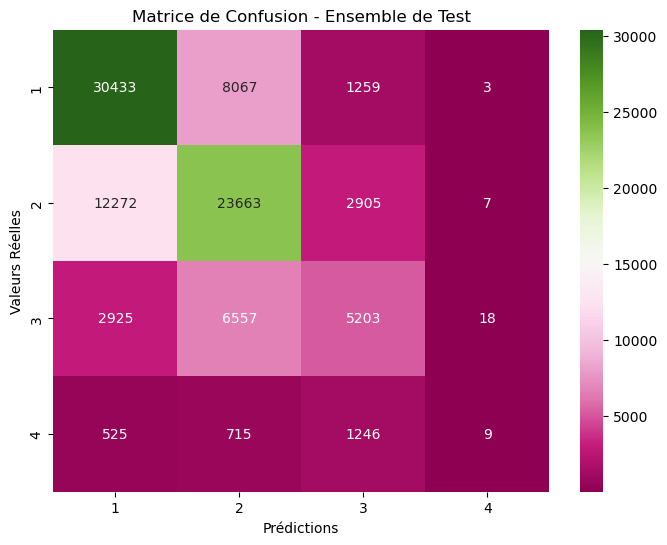

```python
# Affichage stylé de la matrice de confusion pour l'ensemble de test avec Seaborn
plt.figure(figsize=(8, 6))
sns.heatmap(conf_matrix_sub, annot=True, cmap='PiYG', fmt="d", xticklabels=[1, 2, 3, 4], yticklabels=[1, 2, 3, 4])
plt.title('Matrice de Confusion - Ensemble de Test')
plt.xlabel('Prédictions')
plt.ylabel('Valeurs Réelles')
plt.show()
```

###### Afin d'essayer d'améliorer le déséquilibre des classes on va pondérer nos classe différement en utilisant le module class_weight de sklearn, en espérant avoir de meilleur résulatst

```python
from sklearn.utils import class_weight
# Pour la classification multiclasses, la réponse doit être un facteur
train_h2o[y] = train_h2o[y].asfactor()
test_h2o[y] = test_h2o[y].asfactor()

# Calcul des poids des classes
classes_weights = class_weight.compute_class_weight('balanced', classes=np.unique(train_df[y]), y=train_df[y])
classes_weights_dict = dict(enumerate(classes_weights, start=1))
```

```python
# Exécuter AutoML pour 20 modèles de base avec balance des classes
aml = H2OAutoML(max_models=20, max_runtime_secs=1000, seed=1, balance_classes=True, class_sampling_factors=[classes_weights_dict[i] for i in range(1, len(classes_weights) + 1)])
aml.train(x=x, y=y, training_frame=train_h2o)
```

```
AutoML progress: |█
09:24:45.45: AutoML: XGBoost is not available; skipping it.

██████████████████████████████████████████████████████████████| (done) 100%
```

```
Model Details
=============
H2OGradientBoostingEstimator : Gradient Boosting Machine
Model Key: GBM_5_AutoML_2_20240628_92444
```

Model Summary:

|  | number_of_trees | number_of_internal_trees | model_size_in_bytes | min_depth | max_depth | mean_depth | min_leaves | max_leaves | mean_leaves |
| --- | --- | --- | --- | --- | --- | --- | --- | --- | --- |
|  | 155.0 | 620.0 | 517039.0 | 6.0 | 6.0 | 6.0 | 39.0 | 64.0 | 61.748386 |

```
ModelMetricsMultinomial: gbm
** Reported on train data. **

MSE: 0.36521526493319895
RMSE: 0.6043304269463842
LogLoss: 1.0698529812089244
Mean Per-Class Error: 0.4637304908634508
AUC table was not computed: it is either disabled (model parameter 'auc_type' was set to AUTO or NONE) or the domain size exceeds the limit (maximum is 50 domains).
AUCPR table was not computed: it is either disabled (model parameter 'auc_type' was set to AUTO or NONE) or the domain size exceeds the limit (maximum is 50 domains).
```

Confusion Matrix: Row labels: Actual class; Column labels: Predicted class

| 1 | 2 | 3 | 4 | Error | Rate |
| --- | --- | --- | --- | --- | --- |
| 56279.0 | 9325.0 | 1645.0 | 8.0 | 0.1632246 | 10 978 / 67 257 |
| 15403.0 | 46203.0 | 5327.0 | 32.0 | 0.3100426 | 20 762 / 66 965 |
| 8280.0 | 24060.0 | 34721.0 | 157.0 | 0.4834568 | 32 497 / 67 218 |
| 7739.0 | 18822.0 | 34397.0 | 6909.0 | 0.8981979 | 60 958 / 67 867 |
| 87701.0 | 98410.0 | 76090.0 | 7106.0 | 0.4648784 | 125 195 / 269 307 |

Top-4 Hit Ratios:

| k | hit_ratio |
| --- | --- |
| 1 | 0.5351216 |
| 2 | 0.7685318 |
| 3 | 0.9075404 |
| 4 | 1.0 |

```
ModelMetricsMultinomial: gbm
** Reported on validation data. **

MSE: 0.24974567240302242
RMSE: 0.4997456076875738
LogLoss: 0.7337207882185571
Mean Per-Class Error: 0.5007683553524173
AUC table was not computed: it is either disabled (model parameter 'auc_type' was set to AUTO or NONE) or the domain size exceeds the limit (maximum is 50 domains).
AUCPR table was not computed: it is either disabled (model parameter 'auc_type' was set to AUTO or NONE) or the domain size exceeds the limit (maximum is 50 domains).
```

Confusion Matrix: Row labels: Actual class; Column labels: Predicted class

| 1 | 2 | 3 | 4 | Error | Rate |
| --- | --- | --- | --- | --- | --- |
| 13212.0 | 2468.0 | 430.0 | 3.0 | 0.1800410 | 2 901 / 16 113 |
| 3858.0 | 10232.0 | 1457.0 | 7.0 | 0.3421628 | 5 322 / 15 554 |
| 803.0 | 2282.0 | 2774.0 | 42.0 | 0.5299102 | 3 127 / 5 901 |
| 113.0 | 251.0 | 528.0 | 46.0 | 0.9509595 | 892 / 938 |
| 17986.0 | 15233.0 | 5189.0 | 98.0 | 0.3179245 | 12 242 / 38 506 |

Top-4 Hit Ratios:

| k | hit_ratio |
| --- | --- |
| 1 | 0.6820755 |
| 2 | 0.9202462 |
| 3 | 0.9848075 |
| 4 | 1.0 |

Scoring History:

|  | timestamp | duration | number_of_trees | training_rmse | training_logloss | training_classification_error | training_auc | training_pr_auc | validation_rmse | validation_logloss | validation_classification_error | validation_auc | validation_pr_auc |
| --- | --- | --- | --- | --- | --- | --- | --- | --- | --- | --- | --- | --- | --- |
|  | 2024-06-28 09:38:29 | 0.002 sec | 0.0 | 0.7689279 | 1.8307140 | 0.7502590 | nan | nan | 0.6472588 | 1.1087455 | 0.5815457 | nan | nan |
|  | 2024-06-28 09:38:33 | 4.398 sec | 5.0 | 0.7236542 | 1.5901959 | 0.6210941 | nan | nan | 0.5811025 | 0.9267462 | 0.3733184 | nan | nan |
|  | 2024-06-28 09:38:37 | 8.203 sec | 10.0 | 0.6987395 | 1.4651513 | 0.5924614 | nan | nan | 0.5528731 | 0.8542167 | 0.3597361 | nan | nan |
|  | 2024-06-28 09:38:40 | 11.952 sec | 15.0 | 0.6823319 | 1.3891420 | 0.5603976 | nan | nan | 0.5384322 | 0.8185093 | 0.3484652 | nan | nan |
|  | 2024-06-28 09:38:44 | 15.697 sec | 20.0 | 0.6701994 | 1.3369734 | 0.5431979 | nan | nan | 0.5290387 | 0.7960440 | 0.3415831 | nan | nan |
|  | 2024-06-28 09:38:48 | 19.390 sec | 25.0 | 0.6612198 | 1.3000198 | 0.5323293 | nan | nan | 0.5231055 | 0.7826502 | 0.3375058 | nan | nan |
|  | 2024-06-28 09:38:52 | 23.141 sec | 30.0 | 0.6546502 | 1.2733199 | 0.5251999 | nan | nan | 0.5191936 | 0.7740000 | 0.3350127 | nan | nan |
|  | 2024-06-28 09:38:55 | 26.893 sec | 35.0 | 0.6493239 | 1.2517293 | 0.5189022 | nan | nan | 0.5162215 | 0.7674842 | 0.3336623 | nan | nan |
|  | 2024-06-28 09:38:59 | 30.626 sec | 40.0 | 0.6448510 | 1.2333503 | 0.5130724 | nan | nan | 0.5140099 | 0.7626020 | 0.3318704 | nan | nan |
|  | 2024-06-28 09:39:03 | 34.406 sec | 45.0 | 0.6413280 | 1.2187189 | 0.5088653 | nan | nan | 0.5123334 | 0.7590063 | 0.3296889 | nan | nan |
| --- | --- | --- | --- | --- | --- | --- | --- | --- | --- | --- | --- | --- | --- |
|  | 2024-06-28 09:39:52 | 1 min 23.330 sec | 110.0 | 0.6147758 | 1.1123936 | 0.4781086 | nan | nan | 0.5021790 | 0.7378695 | 0.3211707 | nan | nan |
|  | 2024-06-28 09:39:56 | 1 min 26.996 sec | 115.0 | 0.6137026 | 1.1078416 | 0.4763523 | nan | nan | 0.5019349 | 0.7374314 | 0.3207552 | nan | nan |
|  | 2024-06-28 09:39:59 | 1 min 30.729 sec | 120.0 | 0.6123370 | 1.1025197 | 0.4744177 | nan | nan | 0.5015023 | 0.7366539 | 0.3202358 | nan | nan |
|  | 2024-06-28 09:40:03 | 1 min 34.516 sec | 125.0 | 0.6110771 | 1.0973282 | 0.4732777 | nan | nan | 0.5012596 | 0.7362496 | 0.3195866 | nan | nan |
|  | 2024-06-28 09:40:07 | 1 min 38.168 sec | 130.0 | 0.6100270 | 1.0930295 | 0.4720115 | nan | nan | 0.5009088 | 0.7356234 | 0.3191451 | nan | nan |
|  | 2024-06-28 09:40:10 | 1 min 41.863 sec | 135.0 | 0.6087840 | 1.0880872 | 0.4702737 | nan | nan | 0.5006055 | 0.7350949 | 0.3191710 | nan | nan |
|  | 2024-06-28 09:40:14 | 1 min 45.560 sec | 140.0 | 0.6076112 | 1.0832684 | 0.4686139 | nan | nan | 0.5003167 | 0.7346108 | 0.3184179 | nan | nan |
|  | 2024-06-28 09:40:18 | 1 min 49.213 sec | 145.0 | 0.6066458 | 1.0790612 | 0.4675779 | nan | nan | 0.5001733 | 0.7343949 | 0.3184698 | nan | nan |
|  | 2024-06-28 09:40:21 | 1 min 52.893 sec | 150.0 | 0.6054951 | 1.0745142 | 0.4660740 | nan | nan | 0.4999760 | 0.7340447 | 0.3181842 | nan | nan |
|  | 2024-06-28 09:40:25 | 1 min 56.603 sec | 155.0 | 0.6043304 | 1.0698530 | 0.4648784 | nan | nan | 0.4997456 | 0.7337208 | 0.3179245 | nan | nan |

```
[32 rows x 14 columns]
```

Variable Importances:

| variable | relative_importance | scaled_importance | percentage |
| --- | --- | --- | --- |
| com | 51215.8046875 | 1.0 | 0.1508746 |
| secu1 | 39501.3398438 | 0.7712725 | 0.1163654 |
| catv | 25349.6835938 | 0.4949582 | 0.0746766 |
| obs | 22880.9414062 | 0.4467555 | 0.0674040 |
| obsm | 20034.2285156 | 0.3911728 | 0.0590180 |
| an_nais | 17163.6054688 | 0.3351232 | 0.0505616 |
| vma | 13808.6708984 | 0.2696174 | 0.0406784 |
| col | 11799.5595703 | 0.2303890 | 0.0347598 |
| catu_3 | 9527.7607422 | 0.1860317 | 0.0280674 |
| dep | 9295.4375 | 0.1814955 | 0.0273831 |
| --- | --- | --- | --- |
| surf | 939.2497559 | 0.0183391 | 0.0027669 |
| prof | 709.2213745 | 0.0138477 | 0.0020893 |
| an_2020 | 548.7391357 | 0.0107143 | 0.0016165 |
| etatp_1 | 538.5388794 | 0.0105151 | 0.0015865 |
| vosp | 493.4057312 | 0.0096339 | 0.0014535 |
| an_2021 | 333.8605957 | 0.0065187 | 0.0009835 |
| an_2022 | 327.9077759 | 0.0064025 | 0.0009660 |
| secu3 | 289.5260620 | 0.0056531 | 0.0008529 |
| etatp_2 | 204.2686462 | 0.0039884 | 0.0006017 |
| etatp_3 | 135.1227570 | 0.0026383 | 0.0003981 |

```
[52 rows x 4 columns]
```

```
[tips]
Use `model.explain()` to inspect the model.
--
Use `h2o.display.toggle_user_tips()` to switch on/off this section.
```

```python
aml.leader
```

```
Model Details
=============
H2OGradientBoostingEstimator : Gradient Boosting Machine
Model Key: GBM_5_AutoML_2_20240628_92444
```

Model Summary:

|  | number_of_trees | number_of_internal_trees | model_size_in_bytes | min_depth | max_depth | mean_depth | min_leaves | max_leaves | mean_leaves |
| --- | --- | --- | --- | --- | --- | --- | --- | --- | --- |
|  | 155.0 | 620.0 | 517039.0 | 6.0 | 6.0 | 6.0 | 39.0 | 64.0 | 61.748386 |

```
ModelMetricsMultinomial: gbm
** Reported on train data. **

MSE: 0.36521526493319895
RMSE: 0.6043304269463842
LogLoss: 1.0698529812089244
Mean Per-Class Error: 0.4637304908634508
AUC table was not computed: it is either disabled (model parameter 'auc_type' was set to AUTO or NONE) or the domain size exceeds the limit (maximum is 50 domains).
AUCPR table was not computed: it is either disabled (model parameter 'auc_type' was set to AUTO or NONE) or the domain size exceeds the limit (maximum is 50 domains).
```

Confusion Matrix: Row labels: Actual class; Column labels: Predicted class

| 1 | 2 | 3 | 4 | Error | Rate |
| --- | --- | --- | --- | --- | --- |
| 56279.0 | 9325.0 | 1645.0 | 8.0 | 0.1632246 | 10 978 / 67 257 |
| 15403.0 | 46203.0 | 5327.0 | 32.0 | 0.3100426 | 20 762 / 66 965 |
| 8280.0 | 24060.0 | 34721.0 | 157.0 | 0.4834568 | 32 497 / 67 218 |
| 7739.0 | 18822.0 | 34397.0 | 6909.0 | 0.8981979 | 60 958 / 67 867 |
| 87701.0 | 98410.0 | 76090.0 | 7106.0 | 0.4648784 | 125 195 / 269 307 |

Top-4 Hit Ratios:

| k | hit_ratio |
| --- | --- |
| 1 | 0.5351216 |
| 2 | 0.7685318 |
| 3 | 0.9075404 |
| 4 | 1.0 |

```
ModelMetricsMultinomial: gbm
** Reported on validation data. **

MSE: 0.24974567240302242
RMSE: 0.4997456076875738
LogLoss: 0.7337207882185571
Mean Per-Class Error: 0.5007683553524173
AUC table was not computed: it is either disabled (model parameter 'auc_type' was set to AUTO or NONE) or the domain size exceeds the limit (maximum is 50 domains).
AUCPR table was not computed: it is either disabled (model parameter 'auc_type' was set to AUTO or NONE) or the domain size exceeds the limit (maximum is 50 domains).
```

Confusion Matrix: Row labels: Actual class; Column labels: Predicted class

| 1 | 2 | 3 | 4 | Error | Rate |
| --- | --- | --- | --- | --- | --- |
| 13212.0 | 2468.0 | 430.0 | 3.0 | 0.1800410 | 2 901 / 16 113 |
| 3858.0 | 10232.0 | 1457.0 | 7.0 | 0.3421628 | 5 322 / 15 554 |
| 803.0 | 2282.0 | 2774.0 | 42.0 | 0.5299102 | 3 127 / 5 901 |
| 113.0 | 251.0 | 528.0 | 46.0 | 0.9509595 | 892 / 938 |
| 17986.0 | 15233.0 | 5189.0 | 98.0 | 0.3179245 | 12 242 / 38 506 |

Top-4 Hit Ratios:

| k | hit_ratio |
| --- | --- |
| 1 | 0.6820755 |
| 2 | 0.9202462 |
| 3 | 0.9848075 |
| 4 | 1.0 |

Scoring History:

|  | timestamp | duration | number_of_trees | training_rmse | training_logloss | training_classification_error | training_auc | training_pr_auc | validation_rmse | validation_logloss | validation_classification_error | validation_auc | validation_pr_auc |
| --- | --- | --- | --- | --- | --- | --- | --- | --- | --- | --- | --- | --- | --- |
|  | 2024-06-28 09:38:29 | 0.002 sec | 0.0 | 0.7689279 | 1.8307140 | 0.7502590 | nan | nan | 0.6472588 | 1.1087455 | 0.5815457 | nan | nan |
|  | 2024-06-28 09:38:33 | 4.398 sec | 5.0 | 0.7236542 | 1.5901959 | 0.6210941 | nan | nan | 0.5811025 | 0.9267462 | 0.3733184 | nan | nan |
|  | 2024-06-28 09:38:37 | 8.203 sec | 10.0 | 0.6987395 | 1.4651513 | 0.5924614 | nan | nan | 0.5528731 | 0.8542167 | 0.3597361 | nan | nan |
|  | 2024-06-28 09:38:40 | 11.952 sec | 15.0 | 0.6823319 | 1.3891420 | 0.5603976 | nan | nan | 0.5384322 | 0.8185093 | 0.3484652 | nan | nan |
|  | 2024-06-28 09:38:44 | 15.697 sec | 20.0 | 0.6701994 | 1.3369734 | 0.5431979 | nan | nan | 0.5290387 | 0.7960440 | 0.3415831 | nan | nan |
|  | 2024-06-28 09:38:48 | 19.390 sec | 25.0 | 0.6612198 | 1.3000198 | 0.5323293 | nan | nan | 0.5231055 | 0.7826502 | 0.3375058 | nan | nan |
|  | 2024-06-28 09:38:52 | 23.141 sec | 30.0 | 0.6546502 | 1.2733199 | 0.5251999 | nan | nan | 0.5191936 | 0.7740000 | 0.3350127 | nan | nan |
|  | 2024-06-28 09:38:55 | 26.893 sec | 35.0 | 0.6493239 | 1.2517293 | 0.5189022 | nan | nan | 0.5162215 | 0.7674842 | 0.3336623 | nan | nan |
|  | 2024-06-28 09:38:59 | 30.626 sec | 40.0 | 0.6448510 | 1.2333503 | 0.5130724 | nan | nan | 0.5140099 | 0.7626020 | 0.3318704 | nan | nan |
|  | 2024-06-28 09:39:03 | 34.406 sec | 45.0 | 0.6413280 | 1.2187189 | 0.5088653 | nan | nan | 0.5123334 | 0.7590063 | 0.3296889 | nan | nan |
| --- | --- | --- | --- | --- | --- | --- | --- | --- | --- | --- | --- | --- | --- |
|  | 2024-06-28 09:39:52 | 1 min 23.330 sec | 110.0 | 0.6147758 | 1.1123936 | 0.4781086 | nan | nan | 0.5021790 | 0.7378695 | 0.3211707 | nan | nan |
|  | 2024-06-28 09:39:56 | 1 min 26.996 sec | 115.0 | 0.6137026 | 1.1078416 | 0.4763523 | nan | nan | 0.5019349 | 0.7374314 | 0.3207552 | nan | nan |
|  | 2024-06-28 09:39:59 | 1 min 30.729 sec | 120.0 | 0.6123370 | 1.1025197 | 0.4744177 | nan | nan | 0.5015023 | 0.7366539 | 0.3202358 | nan | nan |
|  | 2024-06-28 09:40:03 | 1 min 34.516 sec | 125.0 | 0.6110771 | 1.0973282 | 0.4732777 | nan | nan | 0.5012596 | 0.7362496 | 0.3195866 | nan | nan |
|  | 2024-06-28 09:40:07 | 1 min 38.168 sec | 130.0 | 0.6100270 | 1.0930295 | 0.4720115 | nan | nan | 0.5009088 | 0.7356234 | 0.3191451 | nan | nan |
|  | 2024-06-28 09:40:10 | 1 min 41.863 sec | 135.0 | 0.6087840 | 1.0880872 | 0.4702737 | nan | nan | 0.5006055 | 0.7350949 | 0.3191710 | nan | nan |
|  | 2024-06-28 09:40:14 | 1 min 45.560 sec | 140.0 | 0.6076112 | 1.0832684 | 0.4686139 | nan | nan | 0.5003167 | 0.7346108 | 0.3184179 | nan | nan |
|  | 2024-06-28 09:40:18 | 1 min 49.213 sec | 145.0 | 0.6066458 | 1.0790612 | 0.4675779 | nan | nan | 0.5001733 | 0.7343949 | 0.3184698 | nan | nan |
|  | 2024-06-28 09:40:21 | 1 min 52.893 sec | 150.0 | 0.6054951 | 1.0745142 | 0.4660740 | nan | nan | 0.4999760 | 0.7340447 | 0.3181842 | nan | nan |
|  | 2024-06-28 09:40:25 | 1 min 56.603 sec | 155.0 | 0.6043304 | 1.0698530 | 0.4648784 | nan | nan | 0.4997456 | 0.7337208 | 0.3179245 | nan | nan |

```
[32 rows x 14 columns]
```

Variable Importances:

| variable | relative_importance | scaled_importance | percentage |
| --- | --- | --- | --- |
| com | 51215.8046875 | 1.0 | 0.1508746 |
| secu1 | 39501.3398438 | 0.7712725 | 0.1163654 |
| catv | 25349.6835938 | 0.4949582 | 0.0746766 |
| obs | 22880.9414062 | 0.4467555 | 0.0674040 |
| obsm | 20034.2285156 | 0.3911728 | 0.0590180 |
| an_nais | 17163.6054688 | 0.3351232 | 0.0505616 |
| vma | 13808.6708984 | 0.2696174 | 0.0406784 |
| col | 11799.5595703 | 0.2303890 | 0.0347598 |
| catu_3 | 9527.7607422 | 0.1860317 | 0.0280674 |
| dep | 9295.4375 | 0.1814955 | 0.0273831 |
| --- | --- | --- | --- |
| surf | 939.2497559 | 0.0183391 | 0.0027669 |
| prof | 709.2213745 | 0.0138477 | 0.0020893 |
| an_2020 | 548.7391357 | 0.0107143 | 0.0016165 |
| etatp_1 | 538.5388794 | 0.0105151 | 0.0015865 |
| vosp | 493.4057312 | 0.0096339 | 0.0014535 |
| an_2021 | 333.8605957 | 0.0065187 | 0.0009835 |
| an_2022 | 327.9077759 | 0.0064025 | 0.0009660 |
| secu3 | 289.5260620 | 0.0056531 | 0.0008529 |
| etatp_2 | 204.2686462 | 0.0039884 | 0.0006017 |
| etatp_3 | 135.1227570 | 0.0026383 | 0.0003981 |

```
[52 rows x 4 columns]
```

```
[tips]
Use `model.explain()` to inspect the model.
--
Use `h2o.display.toggle_user_tips()` to switch on/off this section.
```

```python
# Afficher le leaderboard AutoML
lb = aml.leaderboard
lb.head(rows=lb.nrows)  # Imprimer toutes les lignes au lieu de 10 par défaut

# Récupération du meilleur modèle
best_model = aml.leader
```

```python
# Évaluation du meilleur modèle sur l'ensemble de test
perf = best_model.model_performance(test_h2o)
print(perf)
```

```
ModelMetricsMultinomial: gbm
** Reported on test data. **

MSE: 0.24997486493008994
RMSE: 0.4999748642982864
LogLoss: 0.7325316538817649
Mean Per-Class Error: 0.5022904735593181
AUC table was not computed: it is either disabled (model parameter 'auc_type' was set to AUTO or NONE) or the domain size exceeds the limit (maximum is 50 domains).
AUCPR table was not computed: it is either disabled (model parameter 'auc_type' was set to AUTO or NONE) or the domain size exceeds the limit (maximum is 50 domains).

Confusion Matrix: Row labels: Actual class; Column labels: Predicted class
1      2      3      4    Error     Rate
-----  -----  -----  ---  --------  ---------------
32484  6211   1059   8    0.183039  7 278 / 39 762
9561   25545  3710   31   0.34242   13 302 / 38 847
1944   5737   6937   85   0.528192  7 766 / 14 703
293    642    1449   111  0.955511  2 384 / 2 495
44282  38135  13155  235  0.320749  30 730 / 95 807

Top-4 Hit Ratios:
k    hit_ratio
---  -----------
1    0.679251
2    0.920037
3    0.985168
4    1
```

```python
# Obtenir la matrice de confusion H2O
conf_matrix_h2o = perf.confusion_matrix().as_data_frame()

# Extraire les valeurs de la matrice de confusion (ignorer les lignes et colonnes de résumés)
conf_matrix_values = conf_matrix_h2o.iloc[:-1, :-1].values

# Convertir en matrice NumPy
conf_matrix_np = np.array(conf_matrix_values, dtype=int)

# Récupérer uniquement les 4 premières lignes et colonnes
conf_matrix_sub = conf_matrix_np[:4, :4]
```

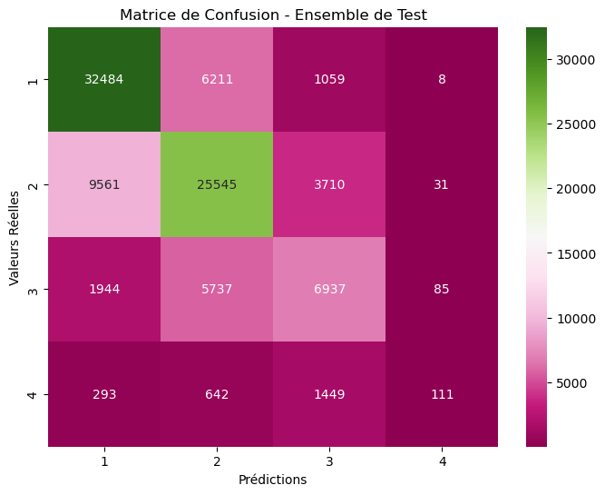

```python
# Affichage stylé de la matrice de confusion pour l'ensemble de test avec Seaborn
plt.figure(figsize=(8, 6))
sns.heatmap(conf_matrix_sub, annot=True, cmap='PiYG', fmt="d", xticklabels=[1, 2, 3, 4], yticklabels=[1, 2, 3, 4])
plt.title('Matrice de Confusion - Ensemble de Test')
plt.xlabel('Prédictions')
plt.ylabel('Valeurs Réelles')
plt.show()
```

```python
# Afficher des métriques détaillées pour chaque classe
print(perf.mean_per_class_error())
```

```
0.5022904735593181
```

#### 5.2.2 Régression logistique multimoniale

```python
from sklearn.linear_model import LogisticRegression
from sklearn.decomposition import PCA
from sklearn.model_selection import train_test_split, GridSearchCV, learning_curve
from sklearn.metrics import classification_report, confusion_matrix, accuracy_score
from sklearn.preprocessing import StandardScaler
import matplotlib.pyplot as plt

# Sélection des variables indépendantes (X) et de la variable dépendante (y)
X = df.drop('grav', axis=1)
y = df['grav']

#Séparation des données avec stratification
X_train, X_test, y_train, y_test = train_test_split(X, y, test_size=0.2, random_state=42, stratify=y)

# Normalisation des données avec StandardScaler
scaler = StandardScaler()
X_train = scaler.fit_transform(X_train)
X_test = scaler.transform(X_test)
```

```python
X_train
```

```
array([[ 0.58987267, -1.69375938,  0.14891447, ..., -0.5903284 ,
         1.71316724, -1.27923852],
       [ 0.58987267,  0.52487653, -1.30871141, ..., -0.5903284 ,
        -0.58371417,  0.78171505],
       [-1.55625693,  0.89464918, -1.72739946, ...,  1.69397237,
        -0.58371417, -1.27923852],
       ...,
       [-1.55625693, -2.43330468,  1.07991969, ..., -0.5903284 ,
        -0.58371417, -1.27923852],
       [ 0.58987267, -0.53161676, -0.87620357, ..., -0.5903284 ,
        -0.58371417,  0.78171505],
       [-1.88322338,  1.47572049, -1.30871141, ...,  1.69397237,
        -0.58371417, -1.27923852]])
```

```python
# Réduction de dimension avec l'ACP
pca = PCA()
X_train_pca = pca.fit_transform(X_train)
X_test_pca = pca.transform(X_test)
# Entraînement du modèle de régression logistique avec optimisation des hyperparamètres

param_grid = {
    'class_weight':['balanced'],
    'max_iter':[1000]
}

grid_search = GridSearchCV(LogisticRegression(), param_grid, scoring='accuracy')
grid_search.fit(X_train_pca, y_train)

# Meilleur modèle après la recherche d'hyperparamètres
best_model = grid_search.best_estimator_


# Entraînement du modèle de régression logistique
best_model.fit(X_train_pca, y_train)
```

```
LogisticRegression(class_weight='balanced', max_iter=1000)
```

```python
# Prédiction sur les ensembles d'apprentissage et de test
y_train_pred = best_model.predict(X_train_pca)
y_test_pred = best_model.predict(X_test_pca)
```

Nous affichons les courbes d'erreurs d'apprentissage et de test afin de vérifier du potentiels surajustement des modèles

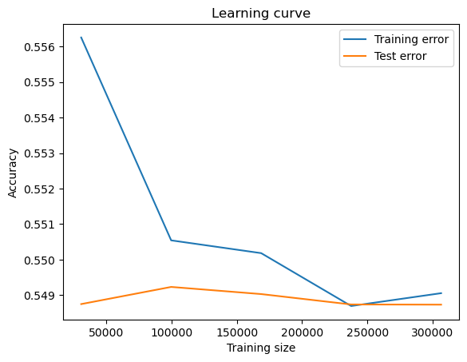

```python
# Visualisation des erreurs d'apprentissage et de test
train_sizes, train_scores, test_scores = learning_curve(best_model, X_train, y_train, scoring='accuracy')

train_scores_mean = train_scores.mean(axis=1)
test_scores_mean = test_scores.mean(axis=1)

plt.figure()
plt.plot(train_sizes, train_scores_mean, label='Training error')
plt.plot(train_sizes, test_scores_mean, label='Test error')
plt.xlabel('Training size')
plt.ylabel('Accuracy')
plt.legend()
plt.title('Learning curve')
plt.show()
```

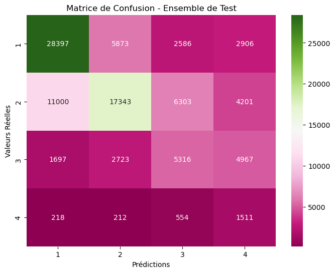

```python
# Calcul de la matrice de confusion pour l'ensemble de test
test_confusion_matrix = confusion_matrix(y_test, y_test_pred)

# Affichage stylé de la matrice de confusion pour l'ensemble de test avec Seaborn
plt.figure(figsize=(8, 6))
sns.heatmap(test_confusion_matrix, annot=True, cmap='PiYG', fmt="d", xticklabels=[1, 2, 3, 4], yticklabels=[1, 2, 3, 4])
plt.title('Matrice de Confusion - Ensemble de Test')
plt.xlabel('Prédictions')
plt.ylabel('Valeurs Réelles')
plt.show()
```

```python
accuracy_pondéré(test_confusion_matrix)
```

```
Precision par classe 1: 0.7142
Precision par classe 2: 0.4464
Precision par classe 3: 0.3616
Precision par classe 4: 0.6056


l'accuracy est de:
```

```
0.5114183305358286
```

```python
"""La suite : Les deux autres modèles ont été implémeté dans le fichier XgBoost"""
```

```
'La suite : Les deux autres modèles ont été implémeté dans le fichier XgBoost'
```